# Salary_re_encoded_Role

## R에서 간단한 처리 이후 이쪽으로 분석 진행.

### 처리내역 :

#### Outlier 및 NA observation 처리 :

- 4분 이하, 4000분 이상 데이터 삭제
- confidence NA 변수 5000여개 삭제
- Salary 중 Student가 높은 salary 갖는 몇 안되는 개체 삭제
- gender = 총 4개의 그룹 중 2개의 small class의 개체들이 다른 패턴 보유, 삭제
- salary = I do not want to disclose 개체 삭제

#### 변수 One Hot Encoding :

- 기존에 One Hot Encoding 되어있는 변수들은 0, 1 로 재코딩
- class를 보유하고 있는 단일변수들은 one hot encoding (get_dummies) 하여 여러 변수로 나누어줌. (ex - Role, Industry, gender, ...)
- 척도형 변수를 갖는 단일 변수도 예외없이 one hot encoding 시킴
- Q34, Q35 = 변수설명상 합쳐서 100이 되는 변수 - 각 개체 값이 1 이하가 되도록 100으로 나눠줌
- 변수 설명상 0~3의 값을 적는 변수 - 각 개체 값이 1 이하가 되도록 3으로 나눠줌.
- 7_Student : industry = Student인 경우와 Role = Student인 경우가 중첩되어 Industry = Student 변수 삭제.
- Q43, Q46 제거함.
- **Role = 앞에서 Data Scientist 효과가 미미해져버린 문제가 생겨 다시코딩. 1. Data Scientiest. 2. Data Analyst 3. Software Engineer 4. DBA/Data Engineer 5. Student 6. Statistician/Research_Analyst 7. Consultant/Manager 8. Other**
- **Confidence level 3개로 재코딩**
- **28, 29, 30 변수들 AWS, Google, Azure, Microsoft, IBM으로 라벨링**

#### 삭제한 변수 내역 :

- Q41 - 앞의 모든 경우에서 collinearity가 발견되어 삭제.
- Q34 : 일반적으로 데이터 사이언스 프로젝트 진행 시 각 업무별로 소요되는 시간 비중 => 앞의 모든 경우에서 변수가 유의하게 나와 한번 빼고 진행. (Q34, Q35는 넣고 빼고 둘다 진행해보기)
- Q34, Q35 모두 넣었을 경우 DS의 coefficient가 0으로 당겨져 버리는 문제 발생. 따라서 빼고 진행해보기로 함.
- Q43 : 진행한 data projects 중 데이터셋내의 'unfair bias'의 탐구와 관련이 있었던 프로젝트의 비율 => 너무 많은 class로 제거
- Q44 : fair 하고 unbiased 한 알고리즘을 확실히 하는 데 가장 많은 어려움을 주는 항목 : 복수 응답 : ex. difficulty in identifying groups that are unfairly targeted. => 역시 너무 많은 class로 제거.
- (앞의 경우 Q43, Q44 모두 Variable Importance 20 내에 들지 못함)

#### Target Variabel Salayr 변형 :

- 총 19개의 multiclass를 가지고 있어, multiclassification 하게 되면 성능이 너무 낮아지는 문제가 발생하여 상위 20%에게 1, 하위 80%에게 0 label을 갖는 top_20 변수를 새로 생성함.

```python
import numpy as np
import pandas as pd
```

```python
from google.colab import drive
drive.mount('/content/drive')
```

```python
multiple = pd.read_csv("/content/drive/My Drive/multiple3.csv", low_memory = False)
```

```python
qschema = pd.read_csv("/content/drive/My Drive/SurveySchema.csv")
```

```python
multiple.head()
```

|  | duration | gender | Age | country | degree | undergraduate_major | Role | industry | Experience | value | Q10 | Q11_Part_1 | Q11_Part_2 | Q11_Part_3 | Q11_Part_4 | Q11_Part_5 | Q11_Part_6 | Q11_Part_7 | Q12_Part_1_TEXT | Q12_Part_2_TEXT | Q12_Part_3_TEXT | Q12_Part_4_TEXT | Q12_Part_5_TEXT | Q13_Part_1 | Q13_Part_2 | Q13_Part_3 | Q13_Part_4 | Q13_Part_5 | Q13_Part_6 | … |
| --- | --- | --- | --- | --- | --- | --- | --- | --- | --- | --- | --- | --- | --- | --- | --- | --- | --- | --- | --- | --- | --- | --- | --- | --- | --- | --- | --- | --- | --- | --- |
| 0 | 710 | Female | 45-49 | NorthAmerica | Doctoral degree | Other | Consultant/Project/Manager | Other | NaN | I do not wish to disclose my approximate yearl... | I do not know | Analyze and understand data to influence produ... | Build and/or run a machine learning service th... | Build and/or run the data infrastructure that ... | NaN | Do research that advances the state of the art... | NaN | NaN | -1 | -1 | -1 | -1 | 0 | Jupyter/IPython | NaN | NaN | NaN | NaN | NaN | … |
| 1 | 434 | Male | 30-34 | Asia | Bachelor’s degree | Engineering (non-computer focused) | Other | Manufacturing/Fabrication | 5-10 | 10-20,000 | No (we do not use ML methods) | NaN | NaN | NaN | NaN | NaN | None of these activities are an important part... | NaN | 1 | -1 | -1 | -1 | -1 | NaN | NaN | NaN | NaN | NaN | NaN | … |
| 2 | 718 | Female | 30-34 | NorthAmerica | Master’s degree | Computer science (software engineering, etc.) | Student | Student | 0-1 | 0-10,000 | I do not know | Analyze and understand data to influence produ... | NaN | NaN | NaN | NaN | NaN | NaN | -1 | -1 | -1 | 0 | -1 | NaN | NaN | NaN | NaN | NaN | NaN | … |
| 3 | 731 | Male | 22-24 | Asia | Master’s degree | Mathematics or statistics | Student | Student | 0-1 | 0-10,000 | I do not know | NaN | NaN | NaN | NaN | NaN | NaN | Other | -1 | 1 | -1 | -1 | -1 | NaN | RStudio | NaN | NaN | NaN | NaN | … |
| 4 | 1142 | Male | 25-29 | SouthAmerica | Bachelor’s degree | Physics or astronomy | Data Scientist | Computers/Technology | 0-1 | I do not wish to disclose my approximate yearl... | We are exploring ML methods (and may one day p... | Analyze and understand data to influence produ... | NaN | NaN | Build prototypes to explore applying machine l... | Do research that advances the state of the art... | NaN | NaN | -1 | -1 | -1 | 2 | -1 | Jupyter/IPython | NaN | NaN | NaN | NaN | Atom | … |

5 rows × 293 columns

```python
## drop Nan in salary
#multiple = multiple[~multiple.value.isnull()].copy()
not_disclosed = multiple[multiple.value == 'I do not wish to disclose my approximate yearly compensation'].index
#multiple = multiple.drop(list(not_disclosed), axis=0)
print(not_disclosed)
```

```
Int64Index([    0,     4,     8,    17,    25,    28,    31,    42,    49,
               59,
            ...
            16472, 16476, 16477, 16480, 16481, 16483, 16485, 16489, 16490,
            16495],
           dtype='int64', length=4003)
```

```python
from pandas.api.types import CategoricalDtype
```

```python
multiple.dtypes
```

```
duration       int64
gender        object
Age           object
country       object
degree        object
               ...
Q29_Part_5    object
Q30_Part_1    object
Q30_Part_2    object
Q30_Part_3    object
Q30_Part_4    object
Length: 293, dtype: object
```

```python
multiple.columns
```

```
Index(['duration', 'gender', 'Age', 'country', 'degree', 'undergraduate_major',
       'Role', 'industry', 'Experience', 'value',
       ...
       'Q28_Part_4', 'Q29_Part_1', 'Q29_Part_2', 'Q29_Part_3', 'Q29_Part_4',
       'Q29_Part_5', 'Q30_Part_1', 'Q30_Part_2', 'Q30_Part_3', 'Q30_Part_4'],
      dtype='object', length=293)
```

```python
multiple.iloc[:,319:321]
```

| 0 |
| --- |
| 1 |
| 2 |
| 3 |
| 4 |
| ... |
| 16491 |
| 16492 |
| 16493 |
| 16494 |
| 16495 |

16496 rows × 0 columns

## Another Dataset :

- Student가 I do not disclose my compensation의 45%를 차지
- gender 2개에서 이상치 생김. 아예 drop하는게?
- Students 패턴 제거 (수입 적음)

```python
gender_trolls = multiple[(multiple.gender == 'Prefer to self-describe') | (multiple.gender == 'Prefer not to say')].index
multiple = multiple.drop(list(gender_trolls), axis=0)
```

```python
student_trolls = multiple[((multiple.Role == 'Student') & (multiple.value > '500,000+')) | \
                     ((multiple.Role == 'Student') & (multiple.value > '400-500,000')) | \
                     ((multiple.Role == 'Student') & (multiple.value > '300-400,000')) | \
                     ((multiple.Role == 'Student') & (multiple.value > '250-300,000'))].index
multiple = multiple.drop(list(student_trolls), axis=0)
```

```python
multiple = multiple[~multiple.value.isnull()].copy()
not_disclosed = multiple[multiple.value == 'I do not wish to disclose my approximate yearly compensation'].index
multiple = multiple.drop(list(not_disclosed), axis=0)
```

```python
multiple.value[1:10]
```

```
2        0-10,000
3        0-10,000
5       10-20,000
6        0-10,000
7       20-30,000
9     125-150,000
11      10-20,000
12      30-40,000
13      50-60,000
Name: value, dtype: object
```

```python
question = multiple.columns
```

```python
question[100:300]
```

```
Index(['Q21_Part_8', 'Q21_Part_9', 'Q21_Part_10', 'Q21_Part_11', 'Q21_Part_12',
       'Q21_Part_13', 'Q23', 'Q24', 'Q25', 'confidence',
       ...
       'Q28_Part_4', 'Q29_Part_1', 'Q29_Part_2', 'Q29_Part_3', 'Q29_Part_4',
       'Q29_Part_5', 'Q30_Part_1', 'Q30_Part_2', 'Q30_Part_3', 'Q30_Part_4'],
      dtype='object', length=193)
```

```python
multiple.dtypes[10:20]
```

```
Q10                object
Q11_Part_1         object
Q11_Part_2         object
Q11_Part_3         object
Q11_Part_4         object
Q11_Part_5         object
Q11_Part_6         object
Q11_Part_7         object
Q12_Part_1_TEXT     int64
Q12_Part_2_TEXT     int64
dtype: object
```

## One Hot Encoding :

```python
import matplotlib.pyplot as plt
import seaborn as sns
from sklearn import preprocessing
sns.set_style('dark')
```

- Role :

```python
len(multiple.Role[multiple.Role.isna()])
```

```
0
```

```python
roledummy = pd.get_dummies(multiple.Role)
```

```python
roledummy.head()
```

|  | Consultant/Project/Manager | Data Analyst | Data Engineer/DBA | Data Scientist | Other | Software Engineer | Statistician/Research Scientist | Student |
| --- | --- | --- | --- | --- | --- | --- | --- | --- |
| 1 | 0 | 0 | 0 | 0 | 1 | 0 | 0 | 0 |
| 2 | 0 | 0 | 0 | 0 | 0 | 0 | 0 | 1 |
| 3 | 0 | 0 | 0 | 0 | 0 | 0 | 0 | 1 |
| 5 | 0 | 0 | 0 | 0 | 1 | 0 | 0 | 0 |
| 6 | 0 | 0 | 0 | 0 | 1 | 0 | 0 | 0 |

- Q1 - Q10 - gender

```python
multiple.gender.unique()
```

```
array(['Male', 'Female'], dtype=object)
```

```python
sex = pd.get_dummies(multiple.gender).iloc[:,:2]
sex.columns=list(map(lambda x:'1_'+x,sex.columns))
```

```python
sex[1:10]
```

|  | 1_Female | 1_Male |
| --- | --- | --- |
| 2 | 1 | 0 |
| 3 | 0 | 1 |
| 5 | 0 | 1 |
| 6 | 0 | 1 |
| 7 | 0 | 1 |
| 9 | 0 | 1 |
| 11 | 1 | 0 |
| 12 | 0 | 1 |
| 13 | 0 | 1 |

```python
ndata = multiple.iloc[:,0]
ndata.head()
```

```
1     434
2     718
3     731
5     959
6    1758
Name: duration, dtype: int64
```

```python
ndata = pd.concat([ndata,sex],axis=1)
ndata.head()
```

|  | duration | 1_Female | 1_Male |
| --- | --- | --- | --- |
| 1 | 434 | 0 | 1 |
| 2 | 718 | 1 | 0 |
| 3 | 731 | 0 | 1 |
| 5 | 959 | 0 | 1 |
| 6 | 1758 | 0 | 1 |

- Q1 - Q10 : 나이

```python
multiple.Age.unique()
```

```
array(['30-34', '22-24', '35-39', '18-21', '40-44', '25-29', '55-59',
       '60-69', '45-49', '50-54', '70-79', '80+'], dtype=object)
```

```python
q2=pd.get_dummies(multiple.Age)
q2.columns=list(map(lambda x: '2_'+x,q2.columns))
ndata = pd.concat([ndata,q2],axis=1)
```

country - one hot encoding

```python
multiple.country.unique()
```

```
array(['Asia', 'NorthAmerica', 'SouthAmerica', 'Europe', 'Africa',
       'Oceania', nan], dtype=object)
```

```python
q3=pd.get_dummies(multiple.country)
```

```python
q3.columns=list(map(lambda x: '3_'+x,q3.columns))
ndata = pd.concat([ndata,q3],axis=1)
```

```python
ndata.info()
```

```
<class 'pandas.core.frame.DataFrame'>
Int64Index: 12190 entries, 1 to 16494
Data columns (total 21 columns):
 #   Column          Non-Null Count  Dtype
---  ------          --------------  -----
 0   duration        12190 non-null  int64
 1   1_Female        12190 non-null  uint8
 2   1_Male          12190 non-null  uint8
 3   2_18-21         12190 non-null  uint8
 4   2_22-24         12190 non-null  uint8
 5   2_25-29         12190 non-null  uint8
 6   2_30-34         12190 non-null  uint8
 7   2_35-39         12190 non-null  uint8
 8   2_40-44         12190 non-null  uint8
 9   2_45-49         12190 non-null  uint8
 10  2_50-54         12190 non-null  uint8
 11  2_55-59         12190 non-null  uint8
 12  2_60-69         12190 non-null  uint8
 13  2_70-79         12190 non-null  uint8
 14  2_80+           12190 non-null  uint8
 15  3_Africa        12190 non-null  uint8
 16  3_Asia          12190 non-null  uint8
 17  3_Europe        12190 non-null  uint8
 18  3_NorthAmerica  12190 non-null  uint8
 19  3_Oceania       12190 non-null  uint8
 20  3_SouthAmerica  12190 non-null  uint8
dtypes: int64(1), uint8(20)
memory usage: 428.6 KB
```

Degree - 교육수준 one hot encoding!

```python
multiple.degree.unique()
```

```
array(['Bachelor’s degree', 'Master’s degree', 'Doctoral degree',
       'Professional degree',
       'Some college/university study without earning a bachelor’s degree',
       'No formal education past high school'], dtype=object)
```

```python
q4 = pd.get_dummies(multiple.degree)
q4.columns=list(map(lambda x: '4_'+x,q4.columns))
ndata = pd.concat([ndata,q4],axis=1)
```

- Role 추가

```python
ndata = pd.concat([ndata, roledummy], axis=1)
```

Major in undergraduated :

```python
multiple.undergraduate_major.unique()
```

```
array(['Engineering (non-computer focused)',
       'Computer science (software engineering, etc.)',
       'Mathematics or statistics',
       'Information technology, networking, or system administration',
       'A business discipline (accounting, economics, finance, etc.)',
       'Environmental science or geology',
       'Medical or life sciences (biology, chemistry, medicine, etc.)',
       'I never declared a major', 'Other', 'Physics or astronomy',
       'Social sciences (anthropology, psychology, sociology, etc.)',
       'Humanities (history, literature, philosophy, etc.)', nan,
       'Fine arts or performing arts'], dtype=object)
```

```python
q5 = pd.get_dummies(multiple.undergraduate_major)
q5.columns=list(map(lambda x: '5_'+x,q5.columns))
ndata = pd.concat([ndata,q5],axis=1)
```

- Industry : 산업군!

```python
q7 = pd.get_dummies(multiple.industry)
q7.columns=list(map(lambda x: '7_'+x,q7.columns))
ndata = pd.concat([ndata,q7],axis=1)
```

- Salary - Target variable!
- experience

```python
q8 = pd.get_dummies(multiple.Experience)
q8.columns=list(map(lambda x: '8_'+x,q8.columns))
ndata = pd.concat([ndata,q8],axis=1)
```

- Q10 - ML 회사 사용?

```python
multiple.columns[1:15]
```

```
Index(['gender', 'Age', 'country', 'degree', 'undergraduate_major', 'Role',
       'industry', 'Experience', 'value', 'Q10', 'Q11_Part_1', 'Q11_Part_2',
       'Q11_Part_3', 'Q11_Part_4'],
      dtype='object')
```

```python
ndata.shape
```

```
(12190, 78)
```

```python
# to dummies :
q10 = pd.get_dummies(multiple.Q10)
q10.columns=list(map(lambda x: '10_'+x,q10.columns))
ndata = pd.concat([ndata,q10],axis=1)
```

```python
ndata.shape
```

```
(12190, 84)
```

- Q11

```python
def to_onehot(i):
    num = 'Q'+str(i)
    q = multiple[[t for t in multiple.columns if num in t]]
    q = q.drop([t for t in q.columns if 'OTHER_TEXT' in t],axis=1)
    q=q.fillna(0)
    q_r = []
    for col in q.columns:
        if q[col].unique()[0]!=0:
            s = q[col].unique()[0]
            q_r.append(s)
        else:
            s = q[col].unique()[1]
            q_r.append(s)
        q[col]=q[col].replace(s,1)
    q.columns=q_r
    return q
```

```python
q11=to_onehot(11)
q11=q11.idxmax(axis=1)
q11.head()
```

```
1    None of these activities are an important part...
2    Analyze and understand data to influence produ...
3                                                Other
5    None of these activities are an important part...
6    Build and/or run a machine learning service th...
dtype: object
```

```python
q11=to_onehot(11)
q11.columns = ['11_'+str(col) for col in q11.columns]
```

```python
#Add None of these & Others - to others
q11.iloc[:,-1]=q11.iloc[:,-2]+q11.iloc[:,-1]
q11=q11.drop(q11.columns[-2],axis=1)
```

```python
ndata=pd.concat([ndata,q11],axis=1)
```

## 원래부터 One-Hot Encoding 된 것들 : Nan -> 0로 바꾸기.

- Q12

```python
q12=multiple[[t for t in multiple.columns if 'Q12' in t]]
q12=q12.iloc[:,1:]
q12=q12.astype(int)
q12[q12!=-1]=1
q12[q12==-1]=0
q12.head()
```

|  | Q12_Part_2_TEXT | Q12_Part_3_TEXT | Q12_Part_4_TEXT | Q12_Part_5_TEXT |
| --- | --- | --- | --- | --- |
| 1 | 0 | 0 | 0 | 0 |
| 2 | 0 | 0 | 1 | 0 |
| 3 | 1 | 0 | 0 | 0 |
| 5 | 0 | 0 | 0 | 0 |
| 6 | 0 | 0 | 1 | 0 |

```python
q12.columns=['12_'+ str(col) for col in q12.columns]
ndata=pd.concat([ndata,q12],axis=1)
```

- Q13

```python
def preprocess_multiple(data,i):
    s='Q'+str(i)
    if s+'_OTHER_TEXT' in data.columns:
        data=data.drop([s+'_OTHER_TEXT'],axis=1)
    df=to_onehot(i)
    df.columns=[str(i)+'_'+str(col) for col in df.columns]
    return df
```

```python
q13=preprocess_multiple(multiple, 13)
ndata=pd.concat([ndata,q13],axis=1)
```

```python
q13.head()
```

|  | 13_Jupyter/IPython | 13_RStudio | 13_PyCharm | 13_Visual Studio Code | 13_nteract | 13_Atom | 13_MATLAB | 13_Visual Studio | 13_Notepad++ | 13_Sublime Text | 13_Vim | 13_IntelliJ | 13_Spyder | 13_None | 13_Other |
| --- | --- | --- | --- | --- | --- | --- | --- | --- | --- | --- | --- | --- | --- | --- | --- |
| 1 | 0 | 0 | 0 | 0 | 0 | 0 | 0 | 0 | 0 | 0 | 0 | 0 | 0 | 1 | 0 |
| 2 | 0 | 0 | 0 | 0 | 0 | 0 | 1 | 0 | 0 | 0 | 0 | 0 | 0 | 0 | 0 |
| 3 | 0 | 1 | 0 | 0 | 0 | 0 | 0 | 0 | 0 | 0 | 0 | 0 | 0 | 0 | 0 |
| 5 | 0 | 1 | 0 | 0 | 0 | 0 | 0 | 0 | 0 | 0 | 0 | 0 | 0 | 0 | 0 |
| 6 | 1 | 0 | 1 | 0 | 0 | 1 | 0 | 1 | 1 | 1 | 0 | 1 | 1 | 0 | 0 |

```python
ndata.shape
```

```
(12190, 109)
```

```python
ndata.iloc[1:5, 60:74]
```

|  | 7_Non-profit/Service | 7_Online Business/Internet-based Sales | 7_Online Service/Internet-based Services | 7_Other | 7_Retail/Sales | 7_Shipping/Transportation | 7_Student | 8_0-1 | 8_1-2 | 8_10-15 | 8_15-20 | 8_2-3 | 8_20-25 | 8_25-30 |
| --- | --- | --- | --- | --- | --- | --- | --- | --- | --- | --- | --- | --- | --- | --- |
| 2 | 0 | 0 | 0 | 0 | 0 | 0 | 1 | 1 | 0 | 0 | 0 | 0 | 0 | 0 |
| 3 | 0 | 0 | 0 | 0 | 0 | 0 | 1 | 1 | 0 | 0 | 0 | 0 | 0 | 0 |
| 5 | 0 | 0 | 0 | 0 | 0 | 0 | 0 | 0 | 0 | 1 | 0 | 0 | 0 | 0 |
| 6 | 0 | 0 | 0 | 1 | 0 | 0 | 0 | 1 | 0 | 0 | 0 | 0 | 0 | 0 |

- Q14

```python
q14=preprocess_multiple(multiple, 14)
ndata=pd.concat([ndata,q14],axis=1)
```

- Q15 - Q16

```python
q15=preprocess_multiple(multiple, 15)
ndata=pd.concat([ndata,q15],axis=1)
```

```python
q16=preprocess_multiple(multiple, 16)
ndata=pd.concat([ndata,q16],axis=1)
```

```python
preprocess_needed = [19, 21]
```

```python
ndata2 = ndata.copy()
```

```python
for i in preprocess_needed :
  q = preprocess_multiple(multiple, i)
  ndata2 = pd.concat([ndata2, q], axis = 1)
```

- Q 23-Q26 : get_dummies

```python
q23=pd.get_dummies(multiple.Q23)
q23.columns=['23_'+str(col) for col in q23.columns]
ndata2=pd.concat([ndata2,q23],axis=1)
```

```python
lst=['I have never written code and I do not want to learn','I have never written code but I want to learn','< 1 year','1-2 years','3-5 years',   '5-10 years',
       '10-20 years', '20-30 years','30-40 years','40+ years']
```

```python
q24=pd.get_dummies(multiple.Q24)
q24.columns=['24_'+str(col) for col in q24.columns]
q24=q24.reindex(columns=list(map(lambda x: '24_'+x,lst)))
ndata2=pd.concat([ndata2,q24],axis=1)
```

- Q25

```python
multiple.Q25.unique()
```

```
array(['I have never studied machine learning but plan to learn in the future',
       '< 1 year', '2-3 years', '5-10 years', '1-2 years', '3-4 years',
       '4-5 years',
       'I have never studied machine learning and I do not plan to',
       '10-15 years', '20+ years'], dtype=object)
```

```python
q25=pd.get_dummies(multiple.Q25)
q25.columns=['25_'+str(col) for col in q25.columns]
ndata2=pd.concat([ndata2,q25],axis=1)
```

- Q26 : confindence

```python
tmp = multiple.confidence.copy()
len(tmp[tmp.isna()])
```

```
0
```

```python
q26=pd.get_dummies(multiple.confidence)
q26.columns=['26_'+str(col) for col in q26.columns]
ndata2=pd.concat([ndata2,q26],axis=1)
```

```python
ndata2.head()
```

|  | duration | 1_Female | 1_Male | 2_18-21 | 2_22-24 | 2_25-29 | 2_30-34 | 2_35-39 | 2_40-44 | 2_45-49 | 2_50-54 | 2_55-59 | 2_60-69 | 2_70-79 | 2_80+ | 3_Africa | 3_Asia | 3_Europe | 3_NorthAmerica | 3_Oceania | 3_SouthAmerica | 4_Bachelor’s degree | 4_Doctoral degree | 4_Master’s degree | 4_No formal education past high school | 4_Professional degree | 4_Some college/university study without earning a bachelor’s degree | Consultant/Project/Manager | Data Analyst | … |
| --- | --- | --- | --- | --- | --- | --- | --- | --- | --- | --- | --- | --- | --- | --- | --- | --- | --- | --- | --- | --- | --- | --- | --- | --- | --- | --- | --- | --- | --- | --- |
| 1 | 434 | 0 | 1 | 0 | 0 | 0 | 1 | 0 | 0 | 0 | 0 | 0 | 0 | 0 | 0 | 0 | 1 | 0 | 0 | 0 | 0 | 1 | 0 | 0 | 0 | 0 | 0 | 0 | 0 | … |
| 2 | 718 | 1 | 0 | 0 | 0 | 0 | 1 | 0 | 0 | 0 | 0 | 0 | 0 | 0 | 0 | 0 | 0 | 0 | 1 | 0 | 0 | 0 | 0 | 1 | 0 | 0 | 0 | 0 | 0 | … |
| 3 | 731 | 0 | 1 | 0 | 1 | 0 | 0 | 0 | 0 | 0 | 0 | 0 | 0 | 0 | 0 | 0 | 1 | 0 | 0 | 0 | 0 | 0 | 0 | 1 | 0 | 0 | 0 | 0 | 0 | … |
| 5 | 959 | 0 | 1 | 0 | 0 | 0 | 0 | 1 | 0 | 0 | 0 | 0 | 0 | 0 | 0 | 0 | 0 | 0 | 0 | 0 | 1 | 0 | 1 | 0 | 0 | 0 | 0 | 0 | 0 | … |
| 6 | 1758 | 0 | 1 | 1 | 0 | 0 | 0 | 0 | 0 | 0 | 0 | 0 | 0 | 0 | 0 | 0 | 1 | 0 | 0 | 0 | 0 | 0 | 0 | 1 | 0 | 0 | 0 | 0 | 0 | … |

5 rows × 206 columns

- Q27-Q31, Q33, Q36, Q38, Q42, Q44, Q45, Q47, Q49, Q50

```python
preprocess_needed = [27, 28, 29, 30, 31, 36]
```

```python
multiple=multiple.drop(['Q38_Part_19'],axis=1)
multiple=multiple.drop(['Q38_Part_20'],axis=1)
```

```python
for i in preprocess_needed :
  q = preprocess_multiple(multiple, i)
  ndata2 = pd.concat([ndata2, q], axis = 1)
```

```python
ndata2.iloc[1:5, 300:310]
ndata2.shape
```

```
(12190, 294)
```

```python
ndata2.head()
```

|  | duration | 1_Female | 1_Male | 2_18-21 | 2_22-24 | 2_25-29 | 2_30-34 | 2_35-39 | 2_40-44 | 2_45-49 | 2_50-54 | 2_55-59 | 2_60-69 | 2_70-79 | 2_80+ | 3_Africa | 3_Asia | 3_Europe | 3_NorthAmerica | 3_Oceania | 3_SouthAmerica | 4_Bachelor’s degree | 4_Doctoral degree | 4_Master’s degree | 4_No formal education past high school | 4_Professional degree | 4_Some college/university study without earning a bachelor’s degree | Consultant/Project/Manager | Data Analyst | … |
| --- | --- | --- | --- | --- | --- | --- | --- | --- | --- | --- | --- | --- | --- | --- | --- | --- | --- | --- | --- | --- | --- | --- | --- | --- | --- | --- | --- | --- | --- | --- |
| 1 | 434 | 0 | 1 | 0 | 0 | 0 | 1 | 0 | 0 | 0 | 0 | 0 | 0 | 0 | 0 | 0 | 1 | 0 | 0 | 0 | 0 | 1 | 0 | 0 | 0 | 0 | 0 | 0 | 0 | … |
| 2 | 718 | 1 | 0 | 0 | 0 | 0 | 1 | 0 | 0 | 0 | 0 | 0 | 0 | 0 | 0 | 0 | 0 | 0 | 1 | 0 | 0 | 0 | 0 | 1 | 0 | 0 | 0 | 0 | 0 | … |
| 3 | 731 | 0 | 1 | 0 | 1 | 0 | 0 | 0 | 0 | 0 | 0 | 0 | 0 | 0 | 0 | 0 | 1 | 0 | 0 | 0 | 0 | 0 | 0 | 1 | 0 | 0 | 0 | 0 | 0 | … |
| 5 | 959 | 0 | 1 | 0 | 0 | 0 | 0 | 1 | 0 | 0 | 0 | 0 | 0 | 0 | 0 | 0 | 0 | 0 | 0 | 0 | 1 | 0 | 1 | 0 | 0 | 0 | 0 | 0 | 0 | … |
| 6 | 1758 | 0 | 1 | 1 | 0 | 0 | 0 | 0 | 0 | 0 | 0 | 0 | 0 | 0 | 0 | 0 | 1 | 0 | 0 | 0 | 0 | 0 | 0 | 1 | 0 | 0 | 0 | 0 | 0 | … |

5 rows × 294 columns

```python
ndata3 = pd.DataFrame
```

```python
ndata3 = ndata2.copy()
```

```python
for i in [38,42,44,45,47,49,50] :
  q = preprocess_multiple(multiple, i)
  ndata3 = pd.concat([ndata3, q], axis = 1)
```

```python
ndata3.iloc[1:4, 310:330]
```

|  | 38_The Data Skeptic Podcast | 38_Medium Blog Posts | 38_None/I do not know | 38_Other | 42_Revenue and/or business goals | 42_Metrics that consider accuracy | 42_Metrics that consider unfair bias | 42_Not applicable (I am not involved with an organization that builds ML models) | 42_Other | 44_Lack of communication between individuals who collect the data and individuals who analyze the data | 44_Difficulty in identifying groups that are unfairly targeted | 44_Difficulty in collecting enough data about groups that may be unfairly targeted | 44_Difficulty in identifying and selecting the appropriate evaluation metrics | 44_I have never found any difficulty in this task | 44_I have never performed this task | 45_Only for very important models that are already in production | 45_For all models right before putting the model in production | 45_When determining whether it is worth it to put the model into production | 45_When building a model that was specifically designed to produce such insights | 45_When first exploring a new ML model or dataset |
| --- | --- | --- | --- | --- | --- | --- | --- | --- | --- | --- | --- | --- | --- | --- | --- | --- | --- | --- | --- | --- |
| 2 | 0 | 0 | 0 | 0 | 0 | 1 | 0 | 0 | 0 | 1 | 0 | 0 | 0 | 0 | 0 | 0 | 0 | 1 | 0 | 0 |
| 3 | 0 | 0 | 0 | 0 | 0 | 0 | 1 | 0 | 0 | 0 | 0 | 1 | 1 | 0 | 0 | 0 | 1 | 1 | 0 | 0 |
| 5 | 0 | 0 | 1 | 0 | 0 | 0 | 0 | 1 | 0 | 0 | 0 | 0 | 0 | 0 | 1 | 0 | 0 | 0 | 1 | 0 |

- Q32

```python
multiple=multiple.drop(['Q32_OTHER'],axis=1)
```

- Q34 : 일반적으로 데이터 사이언스 프로젝트 진행 시 각 업무별로 소요되는 시간 비중 => 빼기.

```python
len(multiple.Q34_Part_1[multiple.Q34_Part_1.isna()])
```

```
1474
```

```python
q34=multiple[[t for t in multiple.columns if 'Q34_' in t]]/100
#ndata3=pd.concat([ndata3,q34],axis=1)
```

```python
q34.head()
```

|  | Q34_Part_1 | Q34_Part_2 | Q34_Part_3 | Q34_Part_4 | Q34_Part_5 | Q34_Part_6 |
| --- | --- | --- | --- | --- | --- | --- |
| 1 | NaN | NaN | NaN | NaN | NaN | NaN |
| 2 | 0.02 | 0.03 | 0.2 | 0.5 | 0.20 | 0.00 |
| 3 | 0.10 | 0.10 | 0.2 | 0.1 | 0.20 | 0.23 |
| 5 | 0.00 | 0.30 | 0.5 | 0.0 | 0.00 | 0.20 |
| 6 | 0.20 | 0.30 | 0.2 | 0.2 | 0.05 | 0.05 |

- Q35

```python
len(multiple.Q35_Part_1[multiple.Q35_Part_1.isna()]) #NA값 마찬가지로 제외하는게 좋을듯
```

```
1585
```

```python
q35=multiple[[t for t in multiple.columns if 'Q35_' in t]]/100
q35.columns=['35_'+str(col) for col in q35.columns]
#ndata3=pd.concat([ndata3, q35],axis=1)
```

- Q40, Q41, Q43, Q46, Q48

```python
multiple.Q40.unique()
```

```
array(['Independent projects are equally important as academic achievements',
       'Independent projects are slightly more important than academic achievements',
       'Independent projects are much more important than academic achievements',
       'Independent projects are much less important than academic achievements',
       'Independent projects are slightly less important than academic achievements',
       'No opinion; I do not know', nan], dtype=object)
```

```python
len(multiple.Q40[multiple.Q40.isna()]) #NA값삭제
```

```
1552
```

```python
q40=pd.get_dummies(multiple.Q40)
q40.columns=['40_'+str(col) for col in q40.columns]
```

```python
ndata3 = pd.concat([ndata3,q40],axis=1)
```

- Q41 => 제거

```python
ndata3.head()
```

|  | duration | 1_Female | 1_Male | 2_18-21 | 2_22-24 | 2_25-29 | 2_30-34 | 2_35-39 | 2_40-44 | 2_45-49 | 2_50-54 | 2_55-59 | 2_60-69 | 2_70-79 | 2_80+ | 3_Africa | 3_Asia | 3_Europe | 3_NorthAmerica | 3_Oceania | 3_SouthAmerica | 4_Bachelor’s degree | 4_Doctoral degree | 4_Master’s degree | 4_No formal education past high school | 4_Professional degree | 4_Some college/university study without earning a bachelor’s degree | Consultant/Project/Manager | Data Analyst | … |
| --- | --- | --- | --- | --- | --- | --- | --- | --- | --- | --- | --- | --- | --- | --- | --- | --- | --- | --- | --- | --- | --- | --- | --- | --- | --- | --- | --- | --- | --- | --- |
| 1 | 434 | 0 | 1 | 0 | 0 | 0 | 1 | 0 | 0 | 0 | 0 | 0 | 0 | 0 | 0 | 0 | 1 | 0 | 0 | 0 | 0 | 1 | 0 | 0 | 0 | 0 | 0 | 0 | 0 | … |
| 2 | 718 | 1 | 0 | 0 | 0 | 0 | 1 | 0 | 0 | 0 | 0 | 0 | 0 | 0 | 0 | 0 | 0 | 0 | 1 | 0 | 0 | 0 | 0 | 1 | 0 | 0 | 0 | 0 | 0 | … |
| 3 | 731 | 0 | 1 | 0 | 1 | 0 | 0 | 0 | 0 | 0 | 0 | 0 | 0 | 0 | 0 | 0 | 1 | 0 | 0 | 0 | 0 | 0 | 0 | 1 | 0 | 0 | 0 | 0 | 0 | … |
| 5 | 959 | 0 | 1 | 0 | 0 | 0 | 0 | 1 | 0 | 0 | 0 | 0 | 0 | 0 | 0 | 0 | 0 | 0 | 0 | 0 | 1 | 0 | 1 | 0 | 0 | 0 | 0 | 0 | 0 | … |
| 6 | 1758 | 0 | 1 | 1 | 0 | 0 | 0 | 0 | 0 | 0 | 0 | 0 | 0 | 0 | 0 | 0 | 1 | 0 | 0 | 0 | 0 | 0 | 0 | 1 | 0 | 0 | 0 | 0 | 0 | … |

5 rows × 373 columns

1 0 Recoding

```python
##Q41
encode = {'Very important':3, 'Slightly important':2,
       'Not at all important':1, 'No opinion; I do not know':0}
q41 = multiple[[i for i in multiple.columns if 'Q41_' in i]]
q41 = q41.replace(encode)
q41 = q41.fillna(0)
q41=q41.astype(int)
q41[q41!=3]=0
q41[q41==3]=1
q41.head()
```

|  | Q41_Part_1 | Q41_Part_2 | Q41_Part_3 |
| --- | --- | --- | --- |
| 1 | 0 | 0 | 0 |
| 2 | 1 | 1 | 1 |
| 3 | 0 | 0 | 1 |
| 5 | 0 | 0 | 1 |
| 6 | 1 | 1 | 1 |

- Q43 : drop - too many classes. 척도형 - 제외

```python
multiple.Q43.unique()
```

```
array([nan, '0-10', '20-30', '0', '10-20', '30-40', '40-50', '90-100',
       '70-80', '50-60', '60-70', '80-90'], dtype=object)
```

```python
len(multiple.Q43[multiple.Q43.isna()]) #NA값 삭제
```

```
3214
```

```python
#numeric encoding
encode = {'0-10':1, '20-30':3, '0':0, '10-20':2, '30-40':4, '60-70':7, '40-50':5,
       '90-100':10, '70-80':8, '50-60':6, '80-90':9}
tmp = multiple.Q43.copy()
tmp = tmp.replace(encode)
```

```python
q43=pd.get_dummies(multiple.Q43)
q43.columns=['43_'+str(col) for col in q43.columns]
#ndata3=pd.concat([ndata3,q43],axis=1)
```

- Q46 - drop : too many classes - 제외

```python
multiple.Q46.unique()
```

```
array([nan, '10-20', '20-30', '0', '50-60', '90-100', '80-90', '0-10',
       '70-80', '30-40', '40-50', '60-70'], dtype=object)
```

```python
#numeric encoding
encode = {'0-10':1, '20-30':3, '0':0, '10-20':2, '30-40':4, '60-70':7, '40-50':5,
       '90-100':10, '70-80':8, '50-60':6, '80-90':9}
tmp = multiple.Q46.copy()
tmp = tmp.replace(encode)
```

```python
q46=pd.get_dummies(multiple.Q46)
q46.columns=['46_'+str(col) for col in q46.columns]
#ndata3=pd.concat([ndata3,q46],axis=1)
```

- Q48

```python
multiple.Q48.unique()
```

```
array([nan,
       'I am confident that I can explain the outputs of most if not all ML models',
       'I am confident that I can understand and explain the outputs of many but not all ML models',
       'I do not know; I have no opinion on the matter',
       'I view ML models as "black boxes" but I am confident that experts are able to explain model outputs',
       'Yes, most ML models are "black boxes"'], dtype=object)
```

```python
q48=pd.get_dummies(multiple.Q48)
q48.columns=['48_'+str(col) for col in q48.columns]
ndata3=pd.concat([ndata3,q48],axis=1)
```

```python
ndata3.shape
```

```
(12190, 378)
```

## Salary :

```python
le = preprocessing.LabelEncoder()
```

```python
le.fit(multiple.value)
le.classes_
```

```
array(['0-10,000', '10-20,000', '100-125,000', '125-150,000',
       '150-200,000', '20-30,000', '200-250,000', '250-300,000',
       '30-40,000', '300-400,000', '40-50,000', '400-500,000',
       '50-60,000', '500,000+', '60-70,000', '70-80,000', '80-90,000',
       '90-100,000'], dtype=object)
```

```python
salary = le.transform(multiple.value)
salary = pd.Series(salary)
salary = salary.rename("value")
```

```python
len(salary)
```

```
12190
```

```python
df_labeled = pd.concat([ndata3, salary], axis=1)
```

```python
df_labeled.shape
```

```
(15189, 379)
```

- 상위 20% 변수 생성

```python
# Define target variable
compensation = multiple.value.str.replace(',', '').str.replace('500000\+', '500-500000').str.split('-')
multiple['yearly_compensation_numerical'] = compensation.apply(lambda x: (int(x[0]) * 1000 + int(x[1]))/ 2) / 1000 # it is calculated in thousand dollars
```

```python
top20flag = multiple.yearly_compensation_numerical.quantile(0.8)
print(top20flag)
```

```
85.0
```

```python
clean_dataset = (multiple.yearly_compensation_numerical > top20flag).reset_index().astype(int)
clean_dataset.columns = ['index', 'top20']
```

```python
len(clean_dataset.loc[clean_dataset['top20']==1, :])
```

```
2267
```

```python
clean_dataset.shape
```

```
(12190, 2)
```

```python
ndata_top = pd.DataFrame()
ndata_top = ndata3.copy()
```

```python
q_overlap = ndata3[[i for i in ndata3.columns if '28_' in i]]
q_overlap.head()
```

|  | 28_DataRobot | 28_H20 Driverless AI | 28_Domino Datalab | 28_SAS | 28_Dataiku | 28_RapidMiner | 28_Instabase | 28_Algorithmia | 28_Dataversity | 28_Cloudera | 28_None | 28_Other | 28_AWS | 28_Google | 28_IBM | 28_Azure |
| --- | --- | --- | --- | --- | --- | --- | --- | --- | --- | --- | --- | --- | --- | --- | --- | --- |
| 1 | 0 | 0 | 0 | 0 | 0 | 0 | 0 | 0 | 0 | 0 | 0 | 0 | 0 | 0 | 0 | 0 |
| 2 | 0 | 0 | 0 | 0 | 0 | 0 | 0 | 0 | 0 | 0 | 0 | 0 | 0 | 0 | 0 | 0 |
| 3 | 0 | 0 | 0 | 0 | 0 | 0 | 0 | 0 | 0 | 1 | 0 | 0 | 0 | 1 | 0 | 1 |
| 5 | 0 | 0 | 0 | 0 | 0 | 0 | 0 | 0 | 0 | 0 | 1 | 0 | 0 | 0 | 0 | 0 |
| 6 | 0 | 0 | 0 | 0 | 0 | 0 | 0 | 0 | 0 | 0 | 1 | 0 | 0 | 0 | 0 | 0 |

```python
# Join with treated questions
for key, value in ndata_top.items():
    value = value.reset_index(drop=True)
    clean_dataset = clean_dataset.join(value, how='left')
```

```python
clean_dataset.top20[1:20]
```

```
1     0
2     0
3     0
4     0
5     0
6     1
7     0
8     0
9     0
10    0
11    1
12    0
13    1
14    0
15    0
16    0
17    0
18    0
19    0
Name: top20, dtype: int64
```

```python
multiple.value[1:20]
```

```
2        0-10,000
3        0-10,000
5       10-20,000
6        0-10,000
7       20-30,000
9     125-150,000
11      10-20,000
12      30-40,000
13      50-60,000
14       0-10,000
15    100-125,000
16      30-40,000
18     90-100,000
19       0-10,000
20      70-80,000
21       0-10,000
22      80-90,000
23      10-20,000
24      10-20,000
Name: value, dtype: object
```

```python
clean_dataset = clean_dataset.drop('index', axis=1)
```

```python
df_labeled.columns[399:401]
```

```
Index([], dtype='object')
```

```python
clean_dataset.shape
```

```
(12190, 379)
```

```python
[col for col in clean_dataset.columns if '47_' in col]
len(clean_dataset['47_Visualising and interpreting predicted vs. actual'][clean_dataset['47_Visualising and interpreting predicted vs. actual']==1])
clean_dataset = clean_dataset.drop(['47_Visualising and interpreting predicted vs. actual'],axis=1)
```

```python
colnames = clean_dataset.columns
colnames[390:410]
```

```
Index([], dtype='object')
```

```python
percent_answer = clean_dataset.sum(axis=0) / clean_dataset.shape[0]

for row in percent_answer.iteritems():
  if row[1] < 0.05 :
    clean_dataset = clean_dataset.drop(row[0], axis=1)
```

- Dropping answers that have less than 5% of repondents - to avoid overfitting.
- 모든 class를 one hot encoding 시켰기 때문에, 5% 미만의 응답을 가진 것도 모두 변수화 되어있다.
- 이런 부분까지 fitting한다면 이 데이터에 대해서만 overfitting이 일어날 가능성이 크다고 판단해, 총 응답 수가 5%보다 낮은 변수/응답은 모두 제거하였다.
- - Dimension Reduction 을 위해서 진행.

```python
clean_dataset.shape
```

```
(12190, 247)
```

```python
clean_dataset.head()
```

|  | top20 | duration | 1_Female | 1_Male | 2_18-21 | 2_22-24 | 2_25-29 | 2_30-34 | 2_35-39 | 2_40-44 | 3_Asia | 3_Europe | 3_NorthAmerica | 3_SouthAmerica | 4_Bachelor’s degree | 4_Doctoral degree | 4_Master’s degree | Consultant/Project/Manager | Data Analyst | Data Scientist | Other | Software Engineer | Statistician/Research Scientist | Student | 5_A business discipline (accounting, economics, finance, etc.) | 5_Computer science (software engineering, etc.) | 5_Engineering (non-computer focused) | 5_Mathematics or statistics | 5_Physics or astronomy | … |
| --- | --- | --- | --- | --- | --- | --- | --- | --- | --- | --- | --- | --- | --- | --- | --- | --- | --- | --- | --- | --- | --- | --- | --- | --- | --- | --- | --- | --- | --- | --- |
| 0 | 0 | 434 | 0 | 1 | 0 | 0 | 0 | 1 | 0 | 0 | 1 | 0 | 0 | 0 | 1 | 0 | 0 | 0 | 0 | 0 | 1 | 0 | 0 | 0 | 0 | 0 | 1 | 0 | 0 | … |
| 1 | 0 | 718 | 1 | 0 | 0 | 0 | 0 | 1 | 0 | 0 | 0 | 0 | 1 | 0 | 0 | 0 | 1 | 0 | 0 | 0 | 0 | 0 | 0 | 1 | 0 | 1 | 0 | 0 | 0 | … |
| 2 | 0 | 731 | 0 | 1 | 0 | 1 | 0 | 0 | 0 | 0 | 1 | 0 | 0 | 0 | 0 | 0 | 1 | 0 | 0 | 0 | 0 | 0 | 0 | 1 | 0 | 0 | 0 | 1 | 0 | … |
| 3 | 0 | 959 | 0 | 1 | 0 | 0 | 0 | 0 | 1 | 0 | 0 | 0 | 0 | 1 | 0 | 1 | 0 | 0 | 0 | 0 | 1 | 0 | 0 | 0 | 0 | 0 | 0 | 0 | 0 | … |
| 4 | 0 | 1758 | 0 | 1 | 1 | 0 | 0 | 0 | 0 | 0 | 1 | 0 | 0 | 0 | 0 | 0 | 1 | 0 | 0 | 0 | 1 | 0 | 0 | 0 | 0 | 0 | 0 | 0 | 0 | … |

5 rows × 247 columns

```python
for c in clean_dataset:
    print(c)
    clean_dataset[c]=pd.to_numeric(clean_dataset[c])
```

```
top20
duration
1_Female
1_Male
2_18-21
2_22-24
2_25-29
2_30-34
2_35-39
2_40-44
3_Asia
3_Europe
3_NorthAmerica
3_SouthAmerica
4_Bachelor’s degree
4_Doctoral degree
4_Master’s degree
Consultant/Project/Manager
Data Analyst
Data Scientist
Other
Software Engineer
Statistician/Research Scientist
Student
5_A business discipline (accounting, economics, finance, etc.)
5_Computer science (software engineering, etc.)
5_Engineering (non-computer focused)
5_Mathematics or statistics
5_Physics or astronomy
7_Academics/Education
7_Accounting/Finance
7_Computers/Technology
7_Other
7_Student
8_0-1
8_1-2
8_10-15
8_2-3
8_3-4
8_4-5
```

[output cut: 192 more lines]

```
50_Too expensive
50_Too time-consuming
50_Requires too much technical knowledge
50_Afraid that others will use my work without giving proper credit
50_Not enough incentives to share my work
50_I had never considered making my work easier for others to reproduce
50_None of these reasons apply to me
40_Independent projects are equally important as academic achievements
40_Independent projects are much more important than academic achievements
40_Independent projects are slightly more important than academic achievements
48_I am confident that I can explain the outputs of most if not all ML models
48_I am confident that I can understand and explain the outputs of many but not all ML models
48_I do not know; I have no opinion on the matter
48_I view ML models as "black boxes" but I am confident that experts are able to explain model outputs
48_Yes, most ML models are "black boxes"
```

```python
clean_dataset.shape
```

```
(12190, 247)
```

- multicollinearity 확인 및 제거

```python
# Create correlation matrix
correl = clean_dataset.corr().abs()

# Select upper triangle of correlation matrix
upper = correl.where(np.triu(np.ones(correl.shape), k=1).astype(np.bool))

# Find index of feature columns with correlation greater than 0.5
to_drop = [column for column in upper.columns if any(upper[column] > 0.5)]

# Drop features
#clean_dataset_dropped = clean_dataset.drop(to_drop, axis=1)

#shape = clean_dataset_dropped.shape
#print('After dropping highly correlated features, our has {} records and {} features'.format(shape[0], shape[1]))
#print('Dropped features: ', to_drop)
```

```python
to_drop
```

```
['1_Male',
 '4_Master’s degree',
 '7_Student',
 '11_Other',
 '14_None',
 '15_I have not used any cloud providers',
 '16_R',
 '16_MATLAB',
 '19_Keras',
 '19_None',
 '21_ggplot2',
 '21_Matplotlib',
 '21_None',
 '25_I have never studied machine learning but plan to learn in the future',
 '26_Definitely yes',
 '26_Maybe',
 '27_AWS Elastic Compute Cloud (EC2)',
 '27_Google Compute Engine',
 '27_Azure Virtual Machines',
 '29_MySQL',
 '30_Google',
 '36_Fast.AI',
 '47_Examine feature importances',
 '49_Make sure the code is human-readable']
```

```python
upper
```

|  | top20 | duration | 1_Female | 1_Male | 2_18-21 | 2_22-24 | 2_25-29 | 2_30-34 | 2_35-39 | 2_40-44 | 3_Asia | 3_Europe | 3_NorthAmerica | 3_SouthAmerica | 4_Bachelor’s degree | 4_Doctoral degree | 4_Master’s degree | Consultant/Project/Manager | Data Analyst | Data Scientist | Other | Software Engineer | Statistician/Research Scientist | Student | 5_A business discipline (accounting, economics, finance, etc.) | 5_Computer science (software engineering, etc.) | 5_Engineering (non-computer focused) | 5_Mathematics or statistics | 5_Physics or astronomy | … |
| --- | --- | --- | --- | --- | --- | --- | --- | --- | --- | --- | --- | --- | --- | --- | --- | --- | --- | --- | --- | --- | --- | --- | --- | --- | --- | --- | --- | --- | --- | --- |
| top20 | NaN | 0.020934 | 0.026885 | 0.026885 | 0.126783 | 0.173103 | 0.123814 | 0.063066 | 0.119663 | 0.098505 | 0.214841 | 0.124693 | 0.444428 | 0.083433 | 0.089124 | 0.100540 | 0.025778 | 0.137778 | 0.071497 | 0.134581 | 0.016691 | 0.000299 | 0.009843 | 0.204977 | 0.043306 | 0.102501 | 0.019409 | 0.018931 | 0.046868 | … |
| duration | NaN | NaN | 0.004238 | 0.004238 | 0.006973 | 0.003973 | 0.002070 | 0.009580 | 0.003936 | 0.002599 | 0.004242 | 0.003735 | 0.021914 | 0.013154 | 0.001754 | 0.005302 | 0.000508 | 0.016577 | 0.003270 | 0.014431 | 0.000071 | 0.007623 | 0.016002 | 0.003621 | 0.012191 | 0.014953 | 0.004828 | 0.012168 | 0.001831 | … |
| 1_Female | NaN | NaN | NaN | 1.000000 | 0.014912 | 0.029629 | 0.032999 | 0.002755 | 0.009757 | 0.022191 | 0.061407 | 0.011339 | 0.098237 | 0.041585 | 0.054839 | 0.032002 | 0.046099 | 0.048798 | 0.046661 | 0.008850 | 0.027120 | 0.065293 | 0.016575 | 0.031485 | 0.012810 | 0.043270 | 0.064052 | 0.063214 | 0.039365 | … |
| 1_Male | NaN | NaN | NaN | NaN | 0.014912 | 0.029629 | 0.032999 | 0.002755 | 0.009757 | 0.022191 | 0.061407 | 0.011339 | 0.098237 | 0.041585 | 0.054839 | 0.032002 | 0.046099 | 0.048798 | 0.046661 | 0.008850 | 0.027120 | 0.065293 | 0.016575 | 0.031485 | 0.012810 | 0.043270 | 0.064052 | 0.063214 | 0.039365 | … |
| 2_18-21 | NaN | NaN | NaN | NaN | NaN | 0.137402 | 0.181805 | 0.141543 | 0.102853 | 0.078180 | 0.148613 | 0.069511 | 0.076364 | 0.003477 | 0.253304 | 0.123077 | 0.186711 | 0.090981 | 0.079563 | 0.113003 | 0.067154 | 0.064218 | 0.066358 | 0.454712 | 0.056912 | 0.137781 | 0.043918 | 0.022895 | 0.043954 | … |
| ... | ... | ... | ... | ... | ... | ... | ... | ... | ... | ... | ... | ... | ... | ... | ... | ... | ... | ... | ... | ... | ... | ... | ... | ... | ... | ... | ... | ... | ... | … |
| 48_I am confident that I can explain the outputs of most if not all ML models | NaN | NaN | NaN | NaN | NaN | NaN | NaN | NaN | NaN | NaN | NaN | NaN | NaN | NaN | NaN | NaN | NaN | NaN | NaN | NaN | NaN | NaN | NaN | NaN | NaN | NaN | NaN | NaN | NaN | … |
| 48_I am confident that I can understand and explain the outputs of many but not all ML models | NaN | NaN | NaN | NaN | NaN | NaN | NaN | NaN | NaN | NaN | NaN | NaN | NaN | NaN | NaN | NaN | NaN | NaN | NaN | NaN | NaN | NaN | NaN | NaN | NaN | NaN | NaN | NaN | NaN | … |
| 48_I do not know; I have no opinion on the matter | NaN | NaN | NaN | NaN | NaN | NaN | NaN | NaN | NaN | NaN | NaN | NaN | NaN | NaN | NaN | NaN | NaN | NaN | NaN | NaN | NaN | NaN | NaN | NaN | NaN | NaN | NaN | NaN | NaN | … |
| 48_I view ML models as "black boxes" but I am confident that experts are able to explain model outputs | NaN | NaN | NaN | NaN | NaN | NaN | NaN | NaN | NaN | NaN | NaN | NaN | NaN | NaN | NaN | NaN | NaN | NaN | NaN | NaN | NaN | NaN | NaN | NaN | NaN | NaN | NaN | NaN | NaN | … |
| 48_Yes, most ML models are "black boxes" | NaN | NaN | NaN | NaN | NaN | NaN | NaN | NaN | NaN | NaN | NaN | NaN | NaN | NaN | NaN | NaN | NaN | NaN | NaN | NaN | NaN | NaN | NaN | NaN | NaN | NaN | NaN | NaN | NaN | … |

247 rows × 247 columns

- 7_Student의 경우 Role = Student와 정확히 일치하기 때문에 변수 제거해줌.

```python
clean_dataset = clean_dataset.drop('7_Student', axis=1)
```

```python
# Finding NANs
df = clean_dataset.isnull().sum().to_frame()
print('We found {} NaNs on the dataset after treatment'.format(df[df[0] > 0].shape[0]))
## 질문을 날리는게 더 낫지않을까? 유의하게 안나오면 질문 날리고 진행해봅시다.
```

```
We found 0 NaNs on the dataset after treatment
```

```python
df[0]
```

```
top20                                                                                                     0
duration                                                                                                  0
1_Female                                                                                                  0
1_Male                                                                                                    0
2_18-21                                                                                                   0
                                                                                                         ..
48_I am confident that I can explain the outputs of most if not all ML models                             0
48_I am confident that I can understand and explain the outputs of many but not all ML models             0
48_I do not know; I have no opinion on the matter                                                         0
48_I view ML models as "black boxes" but I am confident that experts are able to explain model outputs    0
48_Yes, most ML models are "black boxes"                                                                  0
Name: 0, Length: 246, dtype: int64
```

```python
df[df[0]>0]
```

|  | 0 |
| --- | --- |

```python
for c in clean_dataset:
    if len(clean_dataset[clean_dataset[c].isna()])>0:
        clean_dataset=clean_dataset[~clean_dataset[c].isna()]
```

```python
clean_dataset.shape
```

```
(12190, 246)
```

```python
clean_dataset.head()
```

|  | top20 | duration | 1_Female | 1_Male | 2_18-21 | 2_22-24 | 2_25-29 | 2_30-34 | 2_35-39 | 2_40-44 | 3_Asia | 3_Europe | 3_NorthAmerica | 3_SouthAmerica | 4_Bachelor’s degree | 4_Doctoral degree | 4_Master’s degree | Consultant/Project/Manager | Data Analyst | Data Scientist | Other | Software Engineer | Statistician/Research Scientist | Student | 5_A business discipline (accounting, economics, finance, etc.) | 5_Computer science (software engineering, etc.) | 5_Engineering (non-computer focused) | 5_Mathematics or statistics | 5_Physics or astronomy | … |
| --- | --- | --- | --- | --- | --- | --- | --- | --- | --- | --- | --- | --- | --- | --- | --- | --- | --- | --- | --- | --- | --- | --- | --- | --- | --- | --- | --- | --- | --- | --- |
| 0 | 0 | 434 | 0 | 1 | 0 | 0 | 0 | 1 | 0 | 0 | 1 | 0 | 0 | 0 | 1 | 0 | 0 | 0 | 0 | 0 | 1 | 0 | 0 | 0 | 0 | 0 | 1 | 0 | 0 | … |
| 1 | 0 | 718 | 1 | 0 | 0 | 0 | 0 | 1 | 0 | 0 | 0 | 0 | 1 | 0 | 0 | 0 | 1 | 0 | 0 | 0 | 0 | 0 | 0 | 1 | 0 | 1 | 0 | 0 | 0 | … |
| 2 | 0 | 731 | 0 | 1 | 0 | 1 | 0 | 0 | 0 | 0 | 1 | 0 | 0 | 0 | 0 | 0 | 1 | 0 | 0 | 0 | 0 | 0 | 0 | 1 | 0 | 0 | 0 | 1 | 0 | … |
| 3 | 0 | 959 | 0 | 1 | 0 | 0 | 0 | 0 | 1 | 0 | 0 | 0 | 0 | 1 | 0 | 1 | 0 | 0 | 0 | 0 | 1 | 0 | 0 | 0 | 0 | 0 | 0 | 0 | 0 | … |
| 4 | 0 | 1758 | 0 | 1 | 1 | 0 | 0 | 0 | 0 | 0 | 1 | 0 | 0 | 0 | 0 | 0 | 1 | 0 | 0 | 0 | 1 | 0 | 0 | 0 | 0 | 0 | 0 | 0 | 0 | … |

5 rows × 246 columns

```python
clean_dataset.iloc[:,2:]
```

|  | 1_Female | 1_Male | 2_18-21 | 2_22-24 | 2_25-29 | 2_30-34 | 2_35-39 | 2_40-44 | 3_Asia | 3_Europe | 3_NorthAmerica | 3_SouthAmerica | 4_Bachelor’s degree | 4_Doctoral degree | 4_Master’s degree | Consultant/Project/Manager | Data Analyst | Data Scientist | Other | Software Engineer | Statistician/Research Scientist | Student | 5_A business discipline (accounting, economics, finance, etc.) | 5_Computer science (software engineering, etc.) | 5_Engineering (non-computer focused) | 5_Mathematics or statistics | 5_Physics or astronomy | 7_Academics/Education | 7_Accounting/Finance | … |
| --- | --- | --- | --- | --- | --- | --- | --- | --- | --- | --- | --- | --- | --- | --- | --- | --- | --- | --- | --- | --- | --- | --- | --- | --- | --- | --- | --- | --- | --- | --- |
| 0 | 0 | 1 | 0 | 0 | 0 | 1 | 0 | 0 | 1 | 0 | 0 | 0 | 1 | 0 | 0 | 0 | 0 | 0 | 1 | 0 | 0 | 0 | 0 | 0 | 1 | 0 | 0 | 0 | 0 | … |
| 1 | 1 | 0 | 0 | 0 | 0 | 1 | 0 | 0 | 0 | 0 | 1 | 0 | 0 | 0 | 1 | 0 | 0 | 0 | 0 | 0 | 0 | 1 | 0 | 1 | 0 | 0 | 0 | 0 | 0 | … |
| 2 | 0 | 1 | 0 | 1 | 0 | 0 | 0 | 0 | 1 | 0 | 0 | 0 | 0 | 0 | 1 | 0 | 0 | 0 | 0 | 0 | 0 | 1 | 0 | 0 | 0 | 1 | 0 | 0 | 0 | … |
| 3 | 0 | 1 | 0 | 0 | 0 | 0 | 1 | 0 | 0 | 0 | 0 | 1 | 0 | 1 | 0 | 0 | 0 | 0 | 1 | 0 | 0 | 0 | 0 | 0 | 0 | 0 | 0 | 1 | 0 | … |
| 4 | 0 | 1 | 1 | 0 | 0 | 0 | 0 | 0 | 1 | 0 | 0 | 0 | 0 | 0 | 1 | 0 | 0 | 0 | 1 | 0 | 0 | 0 | 0 | 0 | 0 | 0 | 0 | 0 | 0 | … |
| ... | ... | ... | ... | ... | ... | ... | ... | ... | ... | ... | ... | ... | ... | ... | ... | ... | ... | ... | ... | ... | ... | ... | ... | ... | ... | ... | ... | ... | ... | … |
| 12185 | 0 | 1 | 1 | 0 | 0 | 0 | 0 | 0 | 1 | 0 | 0 | 0 | 1 | 0 | 0 | 0 | 0 | 0 | 0 | 0 | 0 | 0 | 0 | 0 | 0 | 1 | 0 | 0 | 0 | … |
| 12186 | 0 | 1 | 0 | 0 | 1 | 0 | 0 | 0 | 0 | 1 | 0 | 0 | 0 | 0 | 1 | 1 | 0 | 0 | 0 | 0 | 0 | 0 | 0 | 1 | 0 | 0 | 0 | 0 | 0 | … |
| 12187 | 1 | 0 | 0 | 1 | 0 | 0 | 0 | 0 | 1 | 0 | 0 | 0 | 0 | 0 | 1 | 0 | 0 | 0 | 0 | 0 | 0 | 1 | 0 | 0 | 0 | 0 | 0 | 0 | 0 | … |
| 12188 | 0 | 1 | 1 | 0 | 0 | 0 | 0 | 0 | 0 | 1 | 0 | 0 | 0 | 0 | 1 | 0 | 0 | 0 | 0 | 0 | 0 | 1 | 0 | 1 | 0 | 0 | 0 | 0 | 0 | … |
| 12189 | 0 | 1 | 0 | 0 | 0 | 1 | 0 | 0 | 0 | 1 | 0 | 0 | 0 | 0 | 1 | 0 | 0 | 0 | 0 | 1 | 0 | 0 | 0 | 1 | 0 | 0 | 0 | 0 | 0 | … |

12190 rows × 244 columns

## Modeling

### Calculating Training Error, Test Error and CV score -

#### Model Selection Method 1. Using Test error/AUC,

#### Model Selection Method 2. Using Cross Validation Score :

- Random Forest, Logistic Regression

```python
from sklearn.model_selection import train_test_split

x = clean_dataset.iloc[:,2:]
y = clean_dataset.iloc[:,0]

x_train, x_test, y_train, y_test = train_test_split(x,y,test_size=0.3,random_state=1234)
```

```python
y.value_counts()
```

```
0    9923
1    2267
Name: top20, dtype: int64
```

```python
from sklearn.metrics import roc_auc_score
from sklearn.metrics import accuracy_score
from sklearn.metrics import confusion_matrix
from sklearn.metrics import precision_score, recall_score
from sklearn.metrics import confusion_matrix, f1_score, roc_auc_score
```

```python
def display_scores(predictor, X, y):

    print('\n### -- ### -- ' + str(type(predictor)).split('.')[-1][:-2] + ' -- ### -- ###')
    # Getting the predicted values
    ypred = predictor.predict(X)
    ypred_score = predictor.predict_proba(X)

    # calculating metrics
    accuracy = accuracy_score(y, ypred)
    roc = roc_auc_score(y, pd.DataFrame(ypred_score)[1])
    confusion = confusion_matrix(y, ypred)

    print('Confusion Matrix: ', confusion)
    print('Accuracy: ', accuracy)
    print('AUC: ', roc)

    type1_error = confusion[0][1] / confusion[0].sum() # False Positive - model predicted in top 20%, while it wasn't
    type2_error = confusion[1][0] / confusion[1].sum() # False Negative - model predicted out of top 20%, while it was

    print('Type 1 error: ', type1_error)
    print('Type 2 error: ', type2_error)
```

- Train Accuracy, AUC, and Confusion Matrix of Logistic Regression and Random Forest

```python
from sklearn.linear_model import LogisticRegression
from sklearn import svm
from sklearn.ensemble import RandomForestClassifier

rforest = RandomForestClassifier(n_estimators=100, random_state=1234)
lreg = LogisticRegression(solver='liblinear', random_state=1234)

# Fit the models
rforest.fit(x_train, y_train)
lreg.fit(x_train, y_train)

# Check some metrics
display_scores(rforest, x_train, y_train)
display_scores(lreg, x_train, y_train)
```

```
### -- ### -- RandomForestClassifier -- ### -- ###
Confusion Matrix:  [[6929    0]
 [   0 1604]]
Accuracy:  1.0
AUC:  1.0
Type 1 error:  0.0
Type 2 error:  0.0

### -- ### -- LogisticRegression -- ### -- ###
Confusion Matrix:  [[6652  277]
 [ 631  973]]
Accuracy:  0.89358959334349
AUC:  0.9218498349306413
Type 1 error:  0.039976908644826094
Type 2 error:  0.3933915211970075
```

=> 결과 해석 :

```python
from sklearn.model_selection import cross_val_score

def do_cv(predictor, X, y, cv):
    print('### -- ### -- ' + str(type(predictor)).split('.')[-1][:-2] + ' -- ### -- ###')
    cv_score = cross_val_score(predictor, X, y, scoring='roc_auc', cv=5)
    print ('Mean AUC score after a 5-fold cross validation: ', cv_score.mean())
    print ('AUC score of each fold: ', cv_score)

do_cv(rforest, x_train, y_train, 5)
print('\n ----------------------------- \n')
do_cv(lreg, x_train, y_train, 5)
print('\n ----------------------------- \n')

RF_cv_score = cross_val_score(rforest, x_train, y_train, scoring='roc_auc', cv=5).mean()
LR_cv_score = cross_val_score(lreg, x_train, y_train, scoring='roc_auc', cv=5).mean()
```

```
### -- ### -- RandomForestClassifier -- ### -- ###
Mean AUC score after a 5-fold cross validation:  0.8843001137725623
AUC score of each fold:  [0.88728743 0.88339784 0.88702333 0.86099049 0.90280149]

 -----------------------------

### -- ### -- LogisticRegression -- ### -- ###
Mean AUC score after a 5-fold cross validation:  0.898512009101878
AUC score of each fold:  [0.89952709 0.89720975 0.90283566 0.88297709 0.91001046]

 -----------------------------
```

- Cross Validation Score for k=5를 해보면, 확실히 위보다 AUC가 많이 떨어진 것을 확인할 수 있다.
- 오히려, Parameter Tunning 이전에는 Logistic Regression이 조금 더 높은 mean AUC score를 여기에서 보여주었다.
- 다만, Seed가 달라지면 결과도 달라질 수 있기 때문에 두 모델이 성능이 거의 비슷한 것으로 판단.
- Random Forest, Logistic Regression : Test Error rate

```python
rforest = RandomForestClassifier(n_estimators=100, random_state=1234)
lreg = LogisticRegression(solver='liblinear', random_state=1234)

# Fit the models
rforest.fit(x_train, y_train)
lreg.fit(x_train, y_train)

# Check some metrics
display_scores(rforest, x_test, y_test)
display_scores(lreg, x_test, y_test)

rf_pred = rforest.predict(x_test)
rf_pred_score = rforest.predict_proba(x_test)

LR_pred = lreg.predict(x_test)
LR_pred_score = lreg.predict_proba(x_test)
# calculating metrics

RF_accuracy = accuracy_score(y_test, rf_pred)
RF_roc = roc_auc_score(y_test, pd.DataFrame(rf_pred_score)[1])

LR_accuracy = accuracy_score(y_test, LR_pred)
LR_roc = roc_auc_score(y_test, pd.DataFrame(LR_pred_score)[1])
```

```
### -- ### -- RandomForestClassifier -- ### -- ###
Confusion Matrix:  [[2933   61]
 [ 412  251]]
Accuracy:  0.8706590101175827
AUC:  0.8867795923672381
Type 1 error:  0.020374081496325986
Type 2 error:  0.6214177978883861

### -- ### -- LogisticRegression -- ### -- ###
Confusion Matrix:  [[2819  175]
 [ 273  390]]
Accuracy:  0.8774952146568226
AUC:  0.9042559729816596
Type 1 error:  0.058450233800935204
Type 2 error:  0.4117647058823529
```

```python
from sklearn import svm

svm = svm.SVC(kernel='linear', random_state=1234)

# Fit the models
svm.fit(x_train, y_train)

ypred = svm.predict(x_train)

# calculating metrics
## SVM Training Error :
accuracy = accuracy_score(y_train, ypred)
confusion = confusion_matrix(y_train, ypred)

print('Confusion Matrix: ', confusion)
print('Accuracy: ', accuracy)
```

```
Confusion Matrix:  [[6659  270]
 [ 635  969]]
Accuracy:  0.8939411695769366
```

```python
from sklearn import svm

svm = svm.SVC(kernel='linear', random_state=1234)

# Fit the models
svm.fit(x_train, y_train)

ypred = svm.predict(x_test)

# calculating metrics
## SVM Training Error :
accuracy = accuracy_score(y_test, ypred)
confusion = confusion_matrix(y_test, ypred)

print('Confusion Matrix: ', confusion)
print('Accuracy: ', accuracy)
SVM_acc = accuracy_score(y_test, ypred)
```

```
Confusion Matrix:  [[2821  173]
 [ 271  392]]
Accuracy:  0.8785890073831009
```

- SVM Test Accuracy :

```python
svm_scores = cross_val_score(svm, x_train, y_train, cv=5, scoring='roc_auc')
```

```python
svm_scores.mean()
```

```
0.8952220643500712
```

- 높은 Cross Validation Score를 보유. (fold = 5)
- Xgboost, Gradient Boosting methods

** XGboost Training Error

```python
x_train.values
```

```
array([[0, 1, 0, ..., 0, 0, 0],
       [0, 1, 0, ..., 0, 0, 0],
       [0, 1, 1, ..., 0, 0, 0],
       ...,
       [0, 1, 0, ..., 0, 1, 0],
       [0, 1, 0, ..., 0, 0, 1],
       [0, 1, 0, ..., 0, 0, 0]])
```

```python
Xg_train = x_train.copy()
Xg_test = x_test.copy()
```

```python
import re

regex = re.compile(r"\[|\]|<", re.IGNORECASE)

Xg_train.columns = [regex.sub("_", col) if any(x in str(col) for x in set(('[', ']', '<'))) else col for col in Xg_train.columns.values]
Xg_test.columns = [regex.sub("_", col) if any(x in str(col) for x in set(('[', ']', '<'))) else col for col in Xg_test.columns.values]
```

- Xgboost Training Error rate :

```python
## 평가시 test dataset을 사용하면 학습에 미리 포함되어 바람직하지 않은, 과적합 문제가 발생할수도 있음.
```

```python
from xgboost import XGBClassifier

xgb_wrapper = XGBClassifier(n_estimators = 400, learning_rate = 0.1, max_depth = 4,
                            eval_metric = "auc", early_stopping_rounds=100)
xgb_wrapper.fit(Xg_train, y_train)
w_preds = xgb_wrapper.predict(Xg_train)
```

```python
def get_clf_eval(y_test, y_pred):
    confusion = confusion_matrix(y_test, y_pred)
    accuracy = accuracy_score(y_test, y_pred)
    precision = precision_score(y_test, y_pred)
    recall = recall_score(y_test, y_pred)
    F1 = f1_score(y_test, y_pred)
    AUC = roc_auc_score(y_test, y_pred)
    print('오차행렬:\n', confusion)
    print('\n정확도: {:.4f}'.format(accuracy))
    print('정밀도: {:.4f}'.format(precision))
    print('재현율: {:.4f}'.format(recall))
    print('F1: {:.4f}'.format(F1))
    print('AUC: {:.4f}'.format(AUC))
```

```python
get_clf_eval(y_train, w_preds)
```

```
오차행렬:
 [[6883   46]
 [ 188 1416]]

정확도: 0.9726
정밀도: 0.9685
재현율: 0.8828
F1: 0.9237
AUC: 0.9381
```

- Xgboost Test Error rate :

```python
from xgboost import XGBClassifier

xgb_wrapper = XGBClassifier(n_estimators = 400, learning_rate = 0.1, max_depth = 4,
                            eval_metric = "auc", early_stopping_rounds=100)
xgb_wrapper.fit(Xg_train, y_train)
w_preds = xgb_wrapper.predict(Xg_test)
```

```python
get_clf_eval(y_test, w_preds)
```

```
오차행렬:
 [[2813  181]
 [ 273  390]]

정확도: 0.8759
정밀도: 0.6830
재현율: 0.5882
F1: 0.6321
AUC: 0.7639
```

```python
XGB_accuracy = accuracy_score(y_test, w_preds)
XGB_auc = roc_auc_score(y_test, w_preds)
```

```python
print(XGB_accuracy, XGB_auc)
```

```
0.875854525567405 0.7638905261503399
```

- 반면, Test Accuracy와 Test AUC는 엄청 떨어진다.

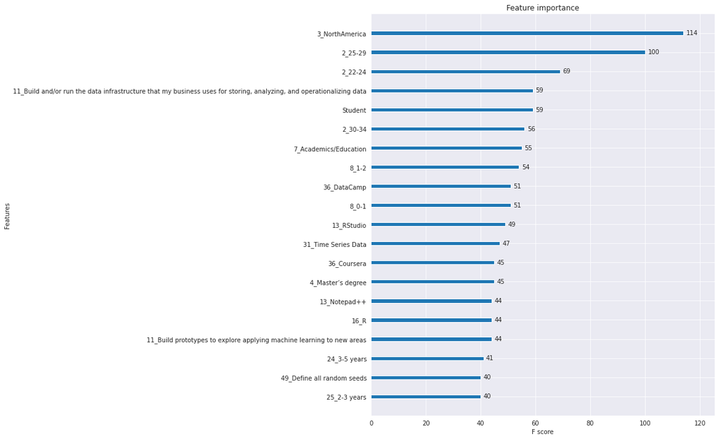

```python
from xgboost import plot_importance
import matplotlib.pyplot as plt
%matplotlib inline

fig, ax = plt.subplots(figsize=(10, 12))

plot_importance(xgb_wrapper, ax=ax, max_num_features = 20)
```

- XGboost Variable Importance Matrix :
- 역시 북미가 가장 큰 영향을 차지하는 것으로 나타남.
- 그 뒤, 나이가 생각보다 많은 영향을 끼친 것으로 드러남.
- 11번도 유의하게?
- 분야로는 Academic/Education이 유의하게 드러남
- 학생 변수 역시 연봉 예측에 중요한 변수. (나이와 아마 관련있을듯)
- 주로 사용하는 Platform : Data camp가 유의하게 드러남.
- 학위로는 Master's degree? (가설 1. -영향력, 가설 2. Manager 계통이 높은 연봉자들이 많이 분포되어있는데, 그들의 학위가 Master's degree에 더 많았다.)
- 언어로는 R
- IDE로는 RStudio

=> **다만 이건 Xgboost의 Variable Importance Plot이므로 Logistic Regression이 택해질 경우 다른 결과가 드러날 가능성이 큼**

** XGboost CV Score :

```python
XGB_auc2 = cross_val_score(xgb_wrapper, X=Xg_train, y=y_train, scoring="roc_auc")
XGB_auc2
```

```
array([0.89303134, 0.89404279, 0.89600725, 0.88853265, 0.90436699])
```

```python
XGB_auc2.mean()
```

```
0.8951962023686144
```

```python
import xgboost as xgb

hr_dmatrix = xgb.DMatrix(data=Xg_train, label=y_train)
```

```python
cv_params = {"objective":"binary:logistic",
             "n_estimators": 100,
             "max_depth":5}

hr_cv = xgb.cv(dtrain=hr_dmatrix,
               params=cv_params,
               nfold=5,
               num_boost_round=10,
               metrics="auc",
               as_pandas=True)
hr_cv
```

|  | train-auc-mean | train-auc-std | test-auc-mean | test-auc-std |
| --- | --- | --- | --- | --- |
| 0 | 0.858837 | 0.005119 | 0.839913 | 0.007561 |
| 1 | 0.883342 | 0.003590 | 0.863886 | 0.005641 |
| 2 | 0.895942 | 0.004499 | 0.873064 | 0.003985 |
| 3 | 0.905298 | 0.001348 | 0.881549 | 0.003278 |
| 4 | 0.909607 | 0.001550 | 0.883881 | 0.003555 |
| 5 | 0.913671 | 0.001153 | 0.887022 | 0.004529 |
| 6 | 0.916633 | 0.001716 | 0.889856 | 0.004220 |
| 7 | 0.920626 | 0.001612 | 0.891688 | 0.004517 |
| 8 | 0.924712 | 0.001331 | 0.893379 | 0.004966 |
| 9 | 0.927808 | 0.002088 | 0.893884 | 0.004933 |

```python
XGB_cv_auc = hr_cv.iloc[:, 2].mean()
XGB_cv_auc
```

```
0.8798122599999999
```

## Model Comparison

### By Cross Validation Score - AUC

```python
CV_table = pd.DataFrame()

CV_table.loc[1,'RF_cv_auc'] = RF_cv_score
CV_table['LR_cv_auc'] = LR_cv_score
CV_table['SVM_cv_auc'] = svm_scores.mean()
CV_table['XGB_cv_auc_cross_val'] = XGB_auc2.mean()
CV_table['XGB_cv_auc_xgb.cv'] = XGB_cv_auc

## Test Data Accuracy and ROC
Acc_table = pd.DataFrame()

Acc_table.loc[1,'RF_acc'] = RF_accuracy
Acc_table['LR_acc'] = LR_accuracy
Acc_table['SVM_acc'] = SVM_acc
Acc_table['XGB_acc'] = XGB_accuracy

AUC_table = pd.DataFrame()

AUC_table.loc[1,'RF_auc'] = RF_roc
AUC_table['LR_auc'] = LR_roc
AUC_table['SVM_auc'] = "None"
AUC_table['XGB_cv_auc'] = XGB_auc
```

```python
CV_table
```

|  | RF_cv_auc | LR_cv_auc | SVM_cv_auc | XGB_cv_auc_cross_val | XGB_cv_auc_xgb.cv |
| --- | --- | --- | --- | --- | --- |
| 1 | 0.8843 | 0.898512 | 0.895222 | 0.895196 | 0.879812 |

```python
Acc_table
```

|  | RF_acc | LR_acc | SVM_acc | XGB_acc |
| --- | --- | --- | --- | --- |
| 1 | 0.870659 | 0.877495 | 0.878589 | 0.875855 |

```python
AUC_table
```

|  | RF_auc | LR_auc | SVM_auc | XGB_cv_auc |
| --- | --- | --- | --- | --- |
| 1 | 0.88678 | 0.904256 | None | 0.763891 |

- Final Result :
- Cross validation 기준 : SVM or XGboost or Logistic Regression 중 선택.
- Accuracy 기준 : SVM, LR, XGB 순서대로.
- AUC 기준 : Logistic Regression이 Best

=> 따라서, Logistic Regression 및 XGB로 Parameter Tuning 실시.

## Parameter Tuning

- Logistic Regression Tunign : L1 vs L2 penalty, C - cost value

```python
from sklearn.model_selection import GridSearchCV
from sklearn.pipeline import Pipeline
```

```python
# Create a logistic regression object with an L2 penalty
logistic = LogisticRegression(solver='liblinear')

pipe = Pipeline(steps=[('logistic', logistic)])

# Create Parameter Space

# Create a list of a sequence of integers from 1 to 30 (the number of features in X + 1)
n_components = list(range(1,x_train.shape[1]+1,1))

# Create a list of values of the regularization parameter
C = np.logspace(-4, 4, 50)
# Create a list of options for the regularization penalty
penalty = ['l1', 'l2']
# Create a dictionary of all the parameter options
# Note has you can access the parameters of steps of a pipeline by using '__’
parameters = dict(logistic__C=C,
                  logistic__penalty=penalty)

# Conduct Parameter Optmization With Pipeline
# Create a grid search object
clf = GridSearchCV(pipe, parameters)

# Fit the grid search
clf.fit(x_train, y_train)
    # View The Best Parameters
print('Best Penalty:', clf.best_estimator_.get_params()['logistic__penalty'])
print('Best C:', clf.best_estimator_.get_params()['logistic__C'])
print(); print(clf.best_estimator_.get_params()['logistic'])

# Use Cross Validation To Evaluate Model
CV_Result = cross_val_score(clf, x_train, y_train, cv=5, n_jobs=-1)
print(); print(CV_Result)
print(); print(CV_Result.mean())
print(); print(CV_Result.std())
```

```
Best Penalty: l2
Best C: 0.2682695795279725

LogisticRegression(C=0.2682695795279725, class_weight=None, dual=False,
                   fit_intercept=True, intercept_scaling=1, l1_ratio=None,
                   max_iter=100, multi_class='auto', n_jobs=None, penalty='l2',
                   random_state=None, solver='liblinear', tol=0.0001, verbose=0,
                   warm_start=False)

[0.88107791 0.87580551 0.86818981 0.87397421 0.8862837 ]

0.8770662282265083

0.006180555958421008
```

```python
# Use Cross Validation To Evaluate Model
CV_Result = cross_val_score(clf, x_train, y_train, cv=5, scoring='roc_auc')
print(); print(CV_Result)
print(); print(CV_Result.mean())
print(); print(CV_Result.std())
```

```
[0.90255919 0.90128926 0.90488777 0.89090458 0.91817313]

0.9035627873411496

0.008736405846338672
```

```python
Logistic = LogisticRegression(solver='liblinear', penalty = 'l1', C = clf.best_estimator_.get_params()['logistic__C'] )
Logistic.fit(x_train, y_train)

LR_pred = Logistic.predict(x_test)
LR_pred_score = Logistic.predict_proba(x_test)
# calculating metrics

LR_tuned_accuracy = accuracy_score(y_test, LR_pred)
LR_tuned_roc = roc_auc_score(y_test, pd.DataFrame(LR_pred_score)[1])
```

```python
print(LR_tuned_accuracy, LR_tuned_roc)
```

```
0.8807765928356577 0.9071652606369098
```

- 전부 tuning 전보다 미세하게나마 상승함. (Test accuracy, test AUC)
- XGB Hyper Parameter Tuning

```python
from sklearn.model_selection import GridSearchCV

# XGBoost 분류기 생성
xgb_clf = xgb.XGBClassifier()

# 초모수 격자생성
xgb_param_grid = {'max_depth': [3,5,7, 9],
              'subsample': [0.6, 0.8, 1.0]}

# Create a GridSearchCV object
hr_grid = GridSearchCV(estimator=xgb_clf,
                       param_grid=xgb_param_grid,
                       scoring='roc_auc',
                       n_jobs=8,
                       cv=5,
                       refit=True,
                       return_train_score=True)

hr_grid.fit(Xg_train, y_train)
```

```
GridSearchCV(cv=5, error_score=nan,
             estimator=XGBClassifier(base_score=0.5, booster='gbtree',
                                     colsample_bylevel=1, colsample_bynode=1,
                                     colsample_bytree=1, gamma=0,
                                     learning_rate=0.1, max_delta_step=0,
                                     max_depth=3, min_child_weight=1,
                                     missing=None, n_estimators=100, n_jobs=1,
                                     nthread=None, objective='binary:logistic',
                                     random_state=0, reg_alpha=0, reg_lambda=1,
                                     scale_pos_weight=1, seed=None, silent=None,
                                     subsample=1, verbosity=1),
             iid='deprecated', n_jobs=8,
             param_grid={'max_depth': [3, 5, 7, 9],
                         'subsample': [0.6, 0.8, 1.0]},
             pre_dispatch='2*n_jobs', refit=True, return_train_score=True,
             scoring='roc_auc', verbose=0)
```

```python
hr_grid_df = pd.DataFrame(hr_grid.cv_results_)
hr_grid_df.loc[:, ['mean_test_score', "params"]]
```

|  | mean_test_score | params |
| --- | --- | --- |
| 0 | 0.902882 | {'max_depth': 3, 'subsample': 0.6} |
| 1 | 0.903967 | {'max_depth': 3, 'subsample': 0.8} |
| 2 | 0.903798 | {'max_depth': 3, 'subsample': 1.0} |
| 3 | 0.900585 | {'max_depth': 5, 'subsample': 0.6} |
| 4 | 0.902640 | {'max_depth': 5, 'subsample': 0.8} |
| 5 | 0.901859 | {'max_depth': 5, 'subsample': 1.0} |
| 6 | 0.897899 | {'max_depth': 7, 'subsample': 0.6} |
| 7 | 0.900655 | {'max_depth': 7, 'subsample': 0.8} |
| 8 | 0.900121 | {'max_depth': 7, 'subsample': 1.0} |
| 9 | 0.899684 | {'max_depth': 9, 'subsample': 0.6} |
| 10 | 0.898722 | {'max_depth': 9, 'subsample': 0.8} |
| 11 | 0.898591 | {'max_depth': 9, 'subsample': 1.0} |

```python
hr_grid_df[hr_grid_df['rank_test_score'] == 1]
```

|  | mean_fit_time | std_fit_time | mean_score_time | std_score_time | param_max_depth | param_subsample | params | split0_test_score | split1_test_score | split2_test_score | split3_test_score | split4_test_score | mean_test_score | std_test_score | rank_test_score | split0_train_score | split1_train_score | split2_train_score | split3_train_score | split4_train_score | mean_train_score | std_train_score |
| --- | --- | --- | --- | --- | --- | --- | --- | --- | --- | --- | --- | --- | --- | --- | --- | --- | --- | --- | --- | --- | --- | --- |
| 1 | 22.1996 | 0.58628 | 0.091078 | 0.012142 | 3 | 0.8 | {'max_depth': 3, 'subsample': 0.8} | 0.903105 | 0.898322 | 0.909646 | 0.891748 | 0.917015 | 0.903967 | 0.008768 | 1 | 0.933037 | 0.934247 | 0.932706 | 0.936424 | 0.931836 | 0.93365 | 0.001588 |

```python
## 최고성능
best_score = hr_grid.best_score_
# 최고성능을 내는 행을 찾아냄
best_row = hr_grid.best_index_

# 최적 초모수: max_depth, subsample
best_max_depth     = hr_grid.best_params_["max_depth"]
best_max_subsample = hr_grid.best_params_["subsample"]

nl = '\n'
print(f'Area Under ROC Cureve (AUC):  \t {best_score:.3f}{nl}\
        인덱스:           \t {best_row}{nl}\
        max_depth:      \t {best_max_depth}{nl}\
        subsample:      \t {best_max_subsample}')
```

```
Area Under ROC Cureve (AUC):  	 0.904
        인덱스:           	 1
        max_depth:      	 3
        subsample:      	 0.8
```

```python
xgb_tuned = XGBClassifier(n_estimators = 400, learning_rate = 0.1, max_depth = best_max_depth,
                            eval_metric = "auc", early_stopping_rounds=100, subsample=best_max_subsample)
xgb_tuned.fit(Xg_train, y_train)
w_preds = xgb_tuned.predict(Xg_test)
```

```python
get_clf_eval(y_test, w_preds)
```

```
오차행렬:
 [[2823  171]
 [ 276  387]]

정확도: 0.8778
정밀도: 0.6935
재현율: 0.5837
F1: 0.6339
AUC: 0.7633
```

```python
XGB_tuned_accuracy = accuracy_score(y_test, w_preds)
XGB_tuned_auc = roc_auc_score(y_test, w_preds)
```

```python
XGB_tuned_cv_Result = cross_val_score(xgb_tuned, Xg_train, y_train, cv=5, scoring='roc_auc')
XGB_tuned_cv_Result.mean()
```

```
0.8995773757511036
```

```python
print("_______Comparison from Former Logistic Regression______ \n")
print("* Accuracy : \n LR_accuracy = {}, LR_tuned_accuracy = {}" .format(LR_accuracy, LR_tuned_accuracy))
print("* Area Under Roc Curve : \n LR_auc = {}, LR_tuned_auc = {}" .format(LR_roc, LR_tuned_roc))
print("* Cross Validation Score : \n LR_cv_auc = {}, LR_cv_tuned_auc = {}" .format(LR_cv_score, CV_Result.mean()))

print("_______Comparison from Former XGBoost______ \n")
print("* Accuracy : \n XGB_accuracy = {}, XGB_tuned_accuracy = {}" .format(XGB_accuracy, XGB_tuned_accuracy))
print("* Area Under Roc Curve : \n XGB_auc = {}, XGB_tuned_auc = {}" .format(XGB_auc, XGB_tuned_auc))
print("* Cross Validation Score(using cross_val_score) : \n XGB_cv_auc = {}, XGB_cv_tuned_auc = {}" .format(XGB_auc2.mean(), XGB_tuned_cv_Result.mean()))
print("* Cross Validation Score(using GridSearchCV) : \n XGB_cv_auc = {}, XGB_cv_tuned_auc = {}" .format(XGB_cv_auc, best_score))
```

```
_______Comparison from Former Logistic Regression______

* Accuracy :
 LR_accuracy = 0.8774952146568226, LR_tuned_accuracy = 0.8807765928356577
* Area Under Roc Curve :
 LR_auc = 0.9042559729816596, LR_tuned_auc = 0.9071652606369098
* Cross Validation Score :
 LR_cv_auc = 0.898512009101878, LR_cv_tuned_auc = 0.9035627873411496
_______Comparison from Former XGBoost______

* Accuracy :
 XGB_accuracy = 0.875854525567405, XGB_tuned_accuracy = 0.8777686628383922
* Area Under Roc Curve :
 XGB_auc = 0.7638905261503399, XGB_tuned_auc = 0.7632980893914526
* Cross Validation Score(using cross_val_score) :
 XGB_cv_auc = 0.8951962023686144, XGB_cv_tuned_auc = 0.8995773757511036
* Cross Validation Score(using GridSearchCV) :
 XGB_cv_auc = 0.8798122599999999, XGB_cv_tuned_auc = 0.9039672758887729
```

## Final Model 선택 :

```python
display_scores(Logistic, x_test, y_test)
```

```
### -- ### -- LogisticRegression -- ### -- ###
Confusion Matrix:  [[2841  153]
 [ 283  380]]
Accuracy:  0.8807765928356577
AUC:  0.9071652606369098
Type 1 error:  0.05110220440881764
Type 2 error:  0.42684766214177977
```

```python
import plotly.graph_objects as go

def gen_layout(charttitle, xtitle, ytitle, annotations=None, lmarg=120, h=400):
    """
    Create layout
    """
    return go.Layout(title=charttitle,
                     height=h,
                     width=800,
                     showlegend=False,
                     xaxis=gen_xaxis(xtitle),
                     yaxis=gen_yaxis(ytitle),
                     annotations = annotations,
                     margin=dict(l=lmarg),
                    )
```

```python
print('Our model\'s intercept is:', Logistic.intercept_[0])
```

```
Our model's intercept is: -0.4568077865930629
```

= Intercept Starts with 0.___ => 여기에서 본인이 가진 특징으로 가감되어 최종 Top20안에 드는 연봉을 받을 수 있는가가 결정됨.

- Psotive Coefficients : positive 답변이 Top 20% 연봉 안에 들 확률을 높인다.
- Negative Coefficients : positive 답변이 Top 20% 연봉 안에 들 확률을 낮춘다.
- Coefficients

```python
features = pd.DataFrame([x_train.columns, Logistic.coef_[0]]).transpose()
features.columns = ['feature', 'coefficient']
features['abs_coefficient'] = features['coefficient'].abs()
```

```python
features.iloc[0:15, :]
```

|  | feature | coefficient | abs_coefficient |
| --- | --- | --- | --- |
| 0 | 1_Female | -0.146921 | 0.146921 |
| 1 | 1_Male | 0 | 0 |
| 2 | 2_18-21 | -1.34217 | 1.34217 |
| 3 | 2_22-24 | -2.04984 | 2.04984 |
| 4 | 2_25-29 | -1.57768 | 1.57768 |
| 5 | 2_30-34 | -0.854547 | 0.854547 |
| 6 | 2_35-39 | -0.236626 | 0.236626 |
| 7 | 2_40-44 | -0.267266 | 0.267266 |
| 8 | 3_Asia | -0.273979 | 0.273979 |
| 9 | 3_Europe | -0.356215 | 0.356215 |
| 10 | 3_NorthAmerica | 2.14933 | 2.14933 |
| 11 | 3_SouthAmerica | -0.902165 | 0.902165 |
| 12 | 4_Bachelor’s degree | 0 | 0 |
| 13 | 4_Doctoral degree | 0.339849 | 0.339849 |
| 14 | 4_Master’s degree | 0.285478 | 0.285478 |

```python
features.tail()
```

|  | feature | coefficient | abs_coefficient |
| --- | --- | --- | --- |
| 239 | 48_I am confident that I can explain the outpu... | 0 | 0 |
| 240 | 48_I am confident that I can understand and ex... | 0.071843 | 0.071843 |
| 241 | 48_I do not know; I have no opinion on the matter | 0 | 0 |
| 242 | 48_I view ML models as "black boxes" but I am ... | -0.031386 | 0.031386 |
| 243 | 48_Yes, most ML models are "black boxes" | 0 | 0 |

```python
features['question_number'] = features.feature.str.split('_').str[0]

features['answer'] = features.feature.str[2:]

features['answer'] = features.answer.apply(lambda x: x[1:] if x[0] == '-' else x)
features['question'] = features['question_number']
```

```python
features.iloc[40:60, :]
```

|  | feature | coefficient | abs_coefficient | question_number | answer | question |
| --- | --- | --- | --- | --- | --- | --- |
| 40 | 10_We are exploring ML methods (and may one da... | -0.0207875 | 0.0207875 | 10 | _We are exploring ML methods (and may one day ... | 10 |
| 41 | 10_We have well established ML methods (i.e., ... | 0.42022 | 0.42022 | 10 | _We have well established ML methods (i.e., mo... | 10 |
| 42 | 10_We recently started using ML methods (i.e.,... | 0 | 0 | 10 | _We recently started using ML methods (i.e., m... | 10 |
| 43 | 10_We use ML methods for generating insights (... | 0.0614055 | 0.0614055 | 10 | _We use ML methods for generating insights (bu... | 10 |
| 44 | 11_Analyze and understand data to influence pr... | 0.00576559 | 0.00576559 | 11 | _Analyze and understand data to influence prod... | 11 |
| 45 | 11_Build and/or run a machine learning service... | 0.124684 | 0.124684 | 11 | _Build and/or run a machine learning service t... | 11 |
| 46 | 11_Build and/or run the data infrastructure th... | 0 | 0 | 11 | _Build and/or run the data infrastructure that... | 11 |
| 47 | 11_Build prototypes to explore applying machin... | 0.308011 | 0.308011 | 11 | _Build prototypes to explore applying machine ... | 11 |
| 48 | 11_Do research that advances the state of the ... | 0 | 0 | 11 | _Do research that advances the state of the ar... | 11 |
| 49 | 11_Other | 0 | 0 | 11 | _Other | 11 |
| 50 | 12_Q12_Part_2_TEXT | -0.0661223 | 0.0661223 | 12 | _Q12_Part_2_TEXT | 12 |
| 51 | 12_Q12_Part_3_TEXT | 0.021995 | 0.021995 | 12 | _Q12_Part_3_TEXT | 12 |
| 52 | 12_Q12_Part_4_TEXT | 0 | 0 | 12 | _Q12_Part_4_TEXT | 12 |
| 53 | 12_Q12_Part_5_TEXT | 0.236716 | 0.236716 | 12 | _Q12_Part_5_TEXT | 12 |
| 54 | 13_Jupyter/IPython | 0 | 0 | 13 | _Jupyter/IPython | 13 |
| 55 | 13_RStudio | -0.139905 | 0.139905 | 13 | _RStudio | 13 |
| 56 | 13_PyCharm | 0.0126911 | 0.0126911 | 13 | _PyCharm | 13 |
| 57 | 13_Visual Studio Code | 0.111261 | 0.111261 | 13 | _Visual Studio Code | 13 |
| 58 | 13_Atom | 0 | 0 | 13 | _Atom | 13 |
| 59 | 13_MATLAB | -0.00370692 | 0.00370692 | 13 | _MATLAB | 13 |

```python
import plotly.graph_objects as go
```

```python
features.iloc[15:21, :]
```

|  | feature | coefficient | abs_coefficient | question_number | answer | question |
| --- | --- | --- | --- | --- | --- | --- |
| 15 | Consultant/Project/Manager | 0.354033 | 0.354033 | Consultant/Project/Manager | nsultant/Project/Manager | Consultant/Project/Manager |
| 16 | Data Analyst | -0.547411 | 0.547411 | Data Analyst | ta Analyst | Data Analyst |
| 17 | Data Scientist | 0.0250826 | 0.0250826 | Data Scientist | ta Scientist | Data Scientist |
| 18 | Other | 0 | 0 | Other | her | Other |
| 19 | Software Engineer | 0.0675337 | 0.0675337 | Software Engineer | ftware Engineer | Software Engineer |
| 20 | Statistician/Research Scientist | -0.0875958 | 0.0875958 | Statistician/Research Scientist | atistician/Research Scientist | Statistician/Research Scientist |

```python
Q6_data = features.iloc[15:21, :]
Q6_data
title = "6_What is Your Role?"
barplot = Q6_data[['feature', 'coefficient']].copy()
barplot.columns = ['y', 'x']
barplot = barplot.sort_values(by='x', ascending = False)
barplot['model_highlight'] = barplot.x > 0
barplot['color'] = barplot.model_highlight.apply(lambda x :'cornflowerblue' if x else 'a')

fig = go.Figure([go.Bar(x = Q6_data.feature, y = Q6_data.coefficient)])
fig.show()
```

[interactive chart not shown]

- L1 Penalty : 효과가 미미한 경우 0으로 보내버림.

- Consultant/Project, Product manager/ Manager 가 엄청 유의하게 나옴. 대체적으로 연봉 높은 사람들이 많이 분포.
- Q13 - 주로 쓰는 IDE

```python
features.iloc[54:67, :]
```

|  | feature | coefficient | abs_coefficient | question_number | answer | question |
| --- | --- | --- | --- | --- | --- | --- |
| 54 | 13_Jupyter/IPython | 0 | 0 | 13 | _Jupyter/IPython | 13 |
| 55 | 13_RStudio | -0.139905 | 0.139905 | 13 | _RStudio | 13 |
| 56 | 13_PyCharm | 0.0126911 | 0.0126911 | 13 | _PyCharm | 13 |
| 57 | 13_Visual Studio Code | 0.111261 | 0.111261 | 13 | _Visual Studio Code | 13 |
| 58 | 13_Atom | 0 | 0 | 13 | _Atom | 13 |
| 59 | 13_MATLAB | -0.00370692 | 0.00370692 | 13 | _MATLAB | 13 |
| 60 | 13_Visual Studio | -0.0357941 | 0.0357941 | 13 | _Visual Studio | 13 |
| 61 | 13_Notepad++ | -0.210707 | 0.210707 | 13 | _Notepad++ | 13 |
| 62 | 13_Sublime Text | 0.0108578 | 0.0108578 | 13 | _Sublime Text | 13 |
| 63 | 13_Vim | 0 | 0 | 13 | _Vim | 13 |
| 64 | 13_IntelliJ | 0 | 0 | 13 | _IntelliJ | 13 |
| 65 | 13_Spyder | 0 | 0 | 13 | _Spyder | 13 |
| 66 | 13_Other | 0.242816 | 0.242816 | 13 | _Other | 13 |

```python
Q13_data = features.iloc[54:67, :]
title = "13_What is IDE?"
barplot = Q13_data[['feature', 'coefficient']].copy()
barplot.columns = ['y', 'x']
barplot = barplot.sort_values(by='x', ascending = False)
barplot['model_highlight'] = barplot.x > 0
barplot['color'] = barplot.model_highlight.apply(lambda x :'cornflowerblue' if x else 'a')

fig = go.Figure([go.Bar(x = Q13_data.feature, y = Q13_data.coefficient)])
fig.show()
```

[interactive chart not shown]

```python
features.iloc[12:15, :]
```

|  | feature | coefficient | abs_coefficient | question_number | answer | question |
| --- | --- | --- | --- | --- | --- | --- |
| 12 | 4_Bachelor’s degree | 0 | 0 | 4 | Bachelor’s degree | 4 |
| 13 | 4_Doctoral degree | 0.339849 | 0.339849 | 4 | Doctoral degree | 4 |
| 14 | 4_Master’s degree | 0.285478 | 0.285478 | 4 | Master’s degree | 4 |

```python
Q4_data = features.iloc[12:15, :]
Q4_data
title = "4_What is the Highest Level of formal education that you have attained or plan to attain within the next 2 years?"
barplot = Q4_data[['answer', 'coefficient']].copy()
barplot.columns = ['y', 'x']
barplot = barplot.sort_values(by='x', ascending = False)
barplot['model_highlight'] = barplot.x > 0
barplot['color'] = barplot.model_highlight.apply(lambda x :'cornflowerblue' if x else 'a')

fig = go.Figure([go.Bar(x = Q4_data.answer, y = Q4_data.coefficient)])
fig.show()
```

[interactive chart not shown]

- Bachelor's degree는 비교적 효과 없음으로 드러남. Doctoral과 Master's degree 는 top 20% 연봉에 유의한 결과를 드러냄.
- Q7 : Industry

```python
features.iloc[26:32, :]
```

|  | feature | coefficient | abs_coefficient | question_number | answer | question |
| --- | --- | --- | --- | --- | --- | --- |
| 26 | 5_Physics or astronomy | 0 | 0 | 5 | Physics or astronomy | 5 |
| 27 | 7_Academics/Education | -1.10323 | 1.10323 | 7 | Academics/Education | 7 |
| 28 | 7_Accounting/Finance | 0.402497 | 0.402497 | 7 | Accounting/Finance | 7 |
| 29 | 7_Computers/Technology | 0 | 0 | 7 | Computers/Technology | 7 |
| 30 | 7_Other | 0 | 0 | 7 | Other | 7 |
| 31 | 8_0-1 | -0.8876 | 0.8876 | 8 | 0-1 | 8 |

```python
Q7_data = features.iloc[27:31, :]

title = "7_How many years of experience do you have in your current role?"
barplot = Q7_data[['answer', 'coefficient']].copy()
barplot.columns = ['y', 'x']
barplot = barplot.sort_values(by='x', ascending = True)
barplot['model_highlight'] = barplot.x > 0
barplot['color'] = barplot.model_highlight.apply(lambda x :'cornflowerblue' if x else 'a')

fig = go.Figure([go.Bar(x = Q7_data.answer, y = Q7_data.coefficient)])
fig.show()
```

[interactive chart not shown]

- Q8 - Experience in current Role

```python
features.iloc[31:39, :]
```

|  | feature | coefficient | abs_coefficient | question_number | answer | question |
| --- | --- | --- | --- | --- | --- | --- |
| 31 | 8_0-1 | -0.8876 | 0.8876 | 8 | 0-1 | 8 |
| 32 | 8_1-2 | -0.919269 | 0.919269 | 8 | 1-2 | 8 |
| 33 | 8_10-15 | -0.0969528 | 0.0969528 | 8 | 10-15 | 8 |
| 34 | 8_2-3 | -0.559927 | 0.559927 | 8 | 2-3 | 8 |
| 35 | 8_3-4 | -0.489585 | 0.489585 | 8 | 3-4 | 8 |
| 36 | 8_4-5 | -0.323903 | 0.323903 | 8 | 4-5 | 8 |
| 37 | 8_5-10 | -0.235463 | 0.235463 | 8 | 5-10 | 8 |
| 38 | 10_I do not know | -0.189082 | 0.189082 | 10 | _I do not know | 10 |

```python
Q8_data = features.iloc[31:38, :]
Q8_data = Q8_data.astype(object)

title = "8_How many years of experience do you have in your current role?"
barplot = Q8_data[['answer', 'coefficient']].copy()
barplot.columns = ['y', 'x']
barplot = barplot.sort_values(by='x', ascending = True)
barplot['model_highlight'] = barplot.x > 0
barplot['color'] = barplot.model_highlight.apply(lambda x :'cornflowerblue' if x else 'a')

fig = go.Figure([go.Bar(x = Q8_data.answer, y = Q8_data.coefficient)])
fig.show()
```

[interactive chart not shown]

- 전부 Negative coefficients.
- 5~10년, 10-15년 경력이 그래도 가장 작은 coef
- 높은 경력자 = 많은 연봉.

```python
* Q10 - 회사에서 ML 사용중?
```

```python
features.iloc[38:44, :]
```

|  | feature | coefficient | abs_coefficient | question_number | answer | question |
| --- | --- | --- | --- | --- | --- | --- |
| 38 | 10_I do not know | -0.189082 | 0.189082 | 10 | _I do not know | 10 |
| 39 | 10_No (we do not use ML methods) | -0.67799 | 0.67799 | 10 | _No (we do not use ML methods) | 10 |
| 40 | 10_We are exploring ML methods (and may one da... | -0.0207875 | 0.0207875 | 10 | _We are exploring ML methods (and may one day ... | 10 |
| 41 | 10_We have well established ML methods (i.e., ... | 0.42022 | 0.42022 | 10 | _We have well established ML methods (i.e., mo... | 10 |
| 42 | 10_We recently started using ML methods (i.e.,... | 0 | 0 | 10 | _We recently started using ML methods (i.e., m... | 10 |
| 43 | 10_We use ML methods for generating insights (... | 0.0614055 | 0.0614055 | 10 | _We use ML methods for generating insights (bu... | 10 |

```python
Q10_data = features.iloc[38:44, :]

title = "10_Select any activities that make up an important part of your role at work"
barplot = Q10_data[['answer', 'coefficient']].copy()
barplot.columns = ['y', 'x']
barplot = barplot.sort_values(by='x', ascending = True)
barplot['model_highlight'] = barplot.x > 0
barplot['color'] = barplot.model_highlight.apply(lambda x :'cornflowerblue' if x else 'a')

fig = go.Figure([go.Bar(x = Q10_data.answer, y = Q10_data.coefficient)])
fig.show()
```

[interactive chart not shown]

- Q11

```python
features.iloc[44:51, :]
```

|  | feature | coefficient | abs_coefficient | question_number | answer | question |
| --- | --- | --- | --- | --- | --- | --- |
| 44 | 11_Analyze and understand data to influence pr... | 0.00576559 | 0.00576559 | 11 | _Analyze and understand data to influence prod... | 11 |
| 45 | 11_Build and/or run a machine learning service... | 0.124684 | 0.124684 | 11 | _Build and/or run a machine learning service t... | 11 |
| 46 | 11_Build and/or run the data infrastructure th... | 0 | 0 | 11 | _Build and/or run the data infrastructure that... | 11 |
| 47 | 11_Build prototypes to explore applying machin... | 0.308011 | 0.308011 | 11 | _Build prototypes to explore applying machine ... | 11 |
| 48 | 11_Do research that advances the state of the ... | 0 | 0 | 11 | _Do research that advances the state of the ar... | 11 |
| 49 | 11_Other | 0 | 0 | 11 | _Other | 11 |
| 50 | 12_Q12_Part_2_TEXT | -0.0661223 | 0.0661223 | 12 | _Q12_Part_2_TEXT | 12 |

```python
Q11_data = features.iloc[44:50, :]

title = "11_Select any activities that make up an important part of your role at work"
barplot = Q11_data[['answer', 'coefficient']].copy()
barplot.columns = ['y', 'x']
barplot = barplot.sort_values(by='x', ascending = True)
barplot['model_highlight'] = barplot.x > 0
barplot['color'] = barplot.model_highlight.apply(lambda x :'cornflowerblue' if x else 'a')

fig = go.Figure([go.Bar(x = Q11_data.answer, y = Q11_data.coefficient)])
fig.show()
```

[interactive chart not shown]

- Building Prototype to explore ML to new areas 가 가장 높은 coef를 갖는 것으로 나타남.
- 그 뒤로는 Build and/or run a service that operationally ~~
- Q12 - 데이터 분석에 주로 사용하는 도구. (큰 분류)

```python
Q12_data = features.iloc[50:54, :]

title = "12_"
barplot = Q12_data[['answer', 'coefficient']].copy()
barplot.columns = ['y', 'x']
barplot = barplot.sort_values(by='x', ascending = True)
barplot['model_highlight'] = barplot.x > 0
barplot['color'] = barplot.model_highlight.apply(lambda x :'cornflowerblue' if x else 'a')

fig = go.Figure([go.Bar(x = Q12_data.answer, y = Q12_data.coefficient)])
fig.show()
```

[interactive chart not shown]

```python
features.iloc[78:91, :]
```

|  | feature | coefficient | abs_coefficient | question_number | answer | question |
| --- | --- | --- | --- | --- | --- | --- |
| 78 | 16_Python | -0.0759136 | 0.0759136 | 16 | _Python | 16 |
| 79 | 16_R | -0.0102173 | 0.0102173 | 16 | _R | 16 |
| 80 | 16_SQL | 0 | 0 | 16 | _SQL | 16 |
| 81 | 16_Bash | 0.0566193 | 0.0566193 | 16 | _Bash | 16 |
| 82 | 16_Java | 0 | 0 | 16 | _Java | 16 |
| 83 | 16_Javascript/Typescript | 0.0557839 | 0.0557839 | 16 | _Javascript/Typescript | 16 |
| 84 | 16_Visual Basic/VBA | -0.111673 | 0.111673 | 16 | _Visual Basic/VBA | 16 |
| 85 | 16_C/C++ | 0.0596717 | 0.0596717 | 16 | _C/C++ | 16 |
| 86 | 16_MATLAB | 0 | 0 | 16 | _MATLAB | 16 |
| 87 | 16_C#/.NET | -0.022701 | 0.022701 | 16 | _C#/.NET | 16 |
| 88 | 16_PHP | -0.412566 | 0.412566 | 16 | _PHP | 16 |
| 89 | 16_SAS/STATA | 0 | 0 | 16 | _SAS/STATA | 16 |
| 90 | 19_Scikit-Learn | 0.0655959 | 0.0655959 | 19 | _Scikit-Learn | 19 |

```python
Q16_data = features.iloc[78:90, :]

title = "12_"
barplot = Q16_data[['answer', 'coefficient']].copy()
barplot.columns = ['y', 'x']
barplot = barplot.sort_values(by='x', ascending = True)
barplot['model_highlight'] = barplot.x > 0
barplot['color'] = barplot.model_highlight.apply(lambda x :'cornflowerblue' if x else 'a')

fig = go.Figure([go.Bar(x = Q16_data.answer, y = Q16_data.coefficient)])
fig.show()
```

[interactive chart not shown]

- Python, R, 모두 - coef
- 오히려 Bash, Javascript, C/C++, 등이 + coef
- 이걸로 보건데, DS 보다는 전문분야 or 전문 프로그래머 Software engineer가 더 높은 연봉.
- Q 19

```python
features.iloc[91:105, :]
```

|  | feature | coefficient | abs_coefficient | question_number | answer | question |
| --- | --- | --- | --- | --- | --- | --- |
| 91 | 19_TensorFlow | -0.0300342 | 0.0300342 | 19 | _TensorFlow | 19 |
| 92 | 19_Keras | 0.064172 | 0.064172 | 19 | _Keras | 19 |
| 93 | 19_PyTorch | 0 | 0 | 19 | _PyTorch | 19 |
| 94 | 19_Spark MLlib | 0.0909973 | 0.0909973 | 19 | _Spark MLlib | 19 |
| 95 | 19_H20 | 0.124303 | 0.124303 | 19 | _H20 | 19 |
| 96 | 19_Fastai | 0.168335 | 0.168335 | 19 | _Fastai | 19 |
| 97 | 19_Caret | 0 | 0 | 19 | _Caret | 19 |
| 98 | 19_Xgboost | 0.0295757 | 0.0295757 | 19 | _Xgboost | 19 |
| 99 | 19_randomForest | 0.0566012 | 0.0566012 | 19 | _randomForest | 19 |
| 100 | 19_lightgbm | 0.16347 | 0.16347 | 19 | _lightgbm | 19 |
| 101 | 19_catboost | 0 | 0 | 19 | _catboost | 19 |
| 102 | 19_Caffe | 0.219026 | 0.219026 | 19 | _Caffe | 19 |
| 103 | 19_None | -0.213974 | 0.213974 | 19 | _None | 19 |
| 104 | 21_ggplot2 | 0 | 0 | 21 | _ggplot2 | 21 |

```python
Q19_data = features.iloc[91:104, :]

title = "19_"
barplot = Q16_data[['answer', 'coefficient']].copy()
barplot.columns = ['y', 'x']
barplot = barplot.sort_values(by='x', ascending = True)
barplot['model_highlight'] = barplot.x > 0
barplot['color'] = barplot.model_highlight.apply(lambda x :'cornflowerblue' if x else 'a')

fig = go.Figure([go.Bar(x = Q19_data.answer, y = Q19_data.coefficient)])
fig.show()
```

[interactive chart not shown]

- 5년간 사용해본 ML frameworks :
- 최근 트렌드 : Keras, H20, Fastai,
- 전통 : Xgboost, RandomForest, Lightgbm
- caffe?는 뭐지??
- 24 : 데이터 분석을 위해 코딩을 해 온 경력 :

```python
Q24_data = features.iloc[118:128, :]
title = "Q24"
barplot = Q24_data[['answer', 'coefficient']].copy()
barplot.columns = ['y', 'x']
barplot = barplot.sort_values(by='x', ascending = True)
barplot['model_highlight'] = barplot.x > 0
barplot['color'] = barplot.model_highlight.apply(lambda x :'cornflowerblue' if x else 'a')

fig = go.Figure([go.Bar(x = Q24_data.answer, y = Q24_data.coefficient)])
fig.show()
```

[interactive chart not shown]

- 코딩 경력 = 많을 수록 좋은 salary.
- 보통 코딩 경력 낮을 수록 연봉 top 20% 안에 들어갈 확률에 -값을 더함.
- Q26 - confidenc

```python
features.iloc[128:132, :]
```

|  | feature | coefficient | abs_coefficient | question_number | answer | question |
| --- | --- | --- | --- | --- | --- | --- |
| 128 | 25_I have never studied machine learning but p... | 0 | 0 | 25 | _I have never studied machine learning but pla... | 25 |
| 129 | 26_Definitely not | 0 | 0 | 26 | _Definitely not | 26 |
| 130 | 26_Definitely yes | -0.166188 | 0.166188 | 26 | _Definitely yes | 26 |
| 131 | 26_Maybe | -0.103257 | 0.103257 | 26 | _Maybe | 26 |

```python
Q26_data = features.iloc[129:132, :]

title = "Q26"
barplot = Q27_data[['answer', 'coefficient']].copy()
barplot.columns = ['y', 'x']
barplot = barplot.sort_values(by='x', ascending = True)
barplot['model_highlight'] = barplot.x > 0
barplot['color'] = barplot.model_highlight.apply(lambda x :'cornflowerblue' if x else 'a')

fig = go.Figure([go.Bar(x = Q26_data.answer, y = Q26_data.coefficient)])
fig.show()
```

[interactive chart not shown]

오히려 Confidence가 높을수록 연봉적으론 낮음.

- 특징 : 높은 경력자들이 오히려 Maybe 쪽에다 투표.
- Q27 - 근 5년간 사용해 본 cloud computing products

```python
features.iloc[132:139, :]
```

|  | feature | coefficient | abs_coefficient | question_number | answer | question |
| --- | --- | --- | --- | --- | --- | --- |
| 132 | 27_AWS Elastic Compute Cloud (EC2) | 0 | 0 | 27 | _AWS Elastic Compute Cloud (EC2) | 27 |
| 133 | 27_Google Compute Engine | 0 | 0 | 27 | _Google Compute Engine | 27 |
| 134 | 27_Google App Engine | 0.114706 | 0.114706 | 27 | _Google App Engine | 27 |
| 135 | 27_AWS Lambda | 0.195504 | 0.195504 | 27 | _AWS Lambda | 27 |
| 136 | 27_Google Cloud Functions | -0.150731 | 0.150731 | 27 | _Google Cloud Functions | 27 |
| 137 | 27_Azure Virtual Machines | -0.0408865 | 0.0408865 | 27 | _Azure Virtual Machines | 27 |
| 138 | 27_None | 0 | 0 | 27 | _None | 27 |

```python
Q27_data = features.iloc[132:139, :]

title = "Q27"
barplot = Q27_data[['answer', 'coefficient']].copy()
barplot.columns = ['y', 'x']
barplot = barplot.sort_values(by='x', ascending = True)
barplot['model_highlight'] = barplot.x > 0
barplot['color'] = barplot.model_highlight.apply(lambda x :'cornflowerblue' if x else 'a')

fig = go.Figure([go.Bar(x = Q27_data.answer, y = Q27_data.coefficient)])
fig.show()
```

[interactive chart not shown]

- Q28, 30 => 5년간 사용한 ML product, Big Data Product

```python
features.iloc[153:158, :]
```

|  | feature | coefficient | abs_coefficient | question_number | answer | question |
| --- | --- | --- | --- | --- | --- | --- |
| 153 | 29_Microsoft | 0 | 0 | 29 | _Microsoft | 29 |
| 154 | 30_Databricks | 0.122349 | 0.122349 | 30 | _Databricks | 30 |
| 155 | 30_None | -0.226886 | 0.226886 | 30 | _None | 30 |
| 156 | 30_AWS | 0.0708066 | 0.0708066 | 30 | _AWS | 30 |
| 157 | 30_Google | 0 | 0 | 30 | _Google | 30 |

```python
Q28_data = features.iloc[139:145, :]

title = "Q28"
barplot = Q28_data[['answer', 'coefficient']].copy()
barplot.columns = ['y', 'x']
barplot = barplot.sort_values(by='x', ascending = True)
barplot['model_highlight'] = barplot.x > 0
barplot['color'] = barplot.model_highlight.apply(lambda x :'cornflowerblue' if x else 'a')

fig = go.Figure([go.Bar(x = Q28_data.answer, y = Q28_data.coefficient)])
fig.show()
```

[interactive chart not shown]

- AWS 계통 ML 프로덕트 쓰는 사람이 더 많았다.
- Sas는 - coef, 하지만 주의해야 하는 것은 Kagglers를 대상으로 했기 때문에, SAS를 사용하는 사람이 적다는 것.

```python
Q30_data = features.iloc[153:158, :]

title = "Q30"
barplot = Q30_data[['answer', 'coefficient']].copy()
barplot.columns = ['y', 'x']
barplot = barplot.sort_values(by='x', ascending = True)
barplot['model_highlight'] = barplot.x > 0
barplot['color'] = barplot.model_highlight.apply(lambda x :'cornflowerblue' if x else 'a')

fig = go.Figure([go.Bar(x = Q30_data.answer, y = Q30_data.coefficient)])
fig.show()
```

[interactive chart not shown]

주로 상위 20% 연봉 kaggler들이 사용한 cloud 상품 = AWS Lambda, Google app engine.

- Q 42 성공적 모델 판단할 때 사용하는 판단기준

```python
features.iloc[192:196, :]
```

|  | feature | coefficient | abs_coefficient | question_number | answer | question |
| --- | --- | --- | --- | --- | --- | --- |
| 192 | 42_Revenue and/or business goals | 0.219088 | 0.219088 | 42 | _Revenue and/or business goals | 42 |
| 193 | 42_Metrics that consider accuracy | -0.125052 | 0.125052 | 42 | _Metrics that consider accuracy | 42 |
| 194 | 42_Metrics that consider unfair bias | 0.224667 | 0.224667 | 42 | _Metrics that consider unfair bias | 42 |
| 195 | 42_Not applicable (I am not involved with an o... | 0.0133623 | 0.0133623 | 42 | _Not applicable (I am not involved with an org... | 42 |

```python
Q42_data = features.iloc[192:196, :]

title = "Q42"
barplot = Q42_data[['answer', 'coefficient']].copy()
barplot.columns = ['y', 'x']
barplot = barplot.sort_values(by='x', ascending = True)
barplot['model_highlight'] = barplot.x > 0
barplot['color'] = barplot.model_highlight.apply(lambda x :'cornflowerblue' if x else 'a')

fig = go.Figure([go.Bar(x = Q42_data.answer, y = Q42_data.coefficient)])
fig.show()
```

[interactive chart not shown]

- 성공적 모델 판단 사용 기준 : Revenue and/ir business goals / Metrics that consider unfair bias
- Q36 : on which online platforms have you begun or complete data science cources?

```python
features.iloc[168:179, :]
```

|  | feature | coefficient | abs_coefficient | question_number | answer | question |
| --- | --- | --- | --- | --- | --- | --- |
| 168 | 36_Udacity | 0.130894 | 0.130894 | 36 | _Udacity | 36 |
| 169 | 36_Coursera | 0.0264072 | 0.0264072 | 36 | _Coursera | 36 |
| 170 | 36_edX | 0 | 0 | 36 | _edX | 36 |
| 171 | 36_DataCamp | -0.171755 | 0.171755 | 36 | _DataCamp | 36 |
| 172 | 36_Kaggle Learn | -0.249828 | 0.249828 | 36 | _Kaggle Learn | 36 |
| 173 | 36_Fast.AI | 0 | 0 | 36 | _Fast.AI | 36 |
| 174 | 36_developers.google.com | -0.00383632 | 0.00383632 | 36 | _developers.google.com | 36 |
| 175 | 36_Udemy | -0.137671 | 0.137671 | 36 | _Udemy | 36 |
| 176 | 36_Online University Courses | 0.120968 | 0.120968 | 36 | _Online University Courses | 36 |
| 177 | 36_None | 0.149901 | 0.149901 | 36 | _None | 36 |
| 178 | 36_Other | 0 | 0 | 36 | _Other | 36 |

```python
Q36_data = features.iloc[168:179, :]

title = "Q36"
barplot = Q36_data[['answer', 'coefficient']].copy()
barplot.columns = ['y', 'x']
barplot = barplot.sort_values(by='x', ascending = True)
barplot['model_highlight'] = barplot.x > 0
barplot['color'] = barplot.model_highlight.apply(lambda x :'cornflowerblue' if x else 'a')

fig = go.Figure([go.Bar(x = Q36_data.answer, y = Q36_data.coefficient)])
fig.show()
```

[interactive chart not shown]

- Udacity - positive corr to top 20% salary kaggers.
- Udemy, Datacamp - negative coef to top 20% salary kagglers => I guess, 초보자들이 많이 듣는 강의사이트?
- Q31 - Which types of data do you currently interact with most often at work or school?

```python
Q31_data = features.iloc[158:168:, :]
title = "Q31"
barplot = Q31_data[['answer', 'coefficient']].copy()
barplot.columns = ['y', 'x']
barplot = barplot.sort_values(by='x', ascending = True)
barplot['model_highlight'] = barplot.x > 0
barplot['color'] = barplot.model_highlight.apply(lambda x :'cornflowerblue' if x else 'a')

fig = go.Figure([go.Bar(x = Q31_data.answer, y = Q31_data.coefficient)])
fig.show()
```

[interactive chart not shown]

- top 20% 연봉 kagglers - 주로 Geospatial Data, Time Series, Video, Categorical Data를 다룸,
- 전문가 = 고학력자 = 특수 분야 이렇게 연관성이 있는듯 하다.
- Text data, Numeric Data ; 상당히 낮은 coefficients
- Q40 : Which better demonstrates expertise in data science : academic achievement or independent projects?

```python
features.iloc[236:249, :]
```

|  | feature | coefficient | abs_coefficient | question_number | answer | question |
| --- | --- | --- | --- | --- | --- | --- |
| 236 | 40_Independent projects are equally important ... | -0.0245028 | 0.0245028 | 40 | _Independent projects are equally important as... | 40 |
| 237 | 40_Independent projects are much more importan... | 0 | 0 | 40 | _Independent projects are much more important ... | 40 |
| 238 | 40_Independent projects are slightly more impo... | 0 | 0 | 40 | _Independent projects are slightly more import... | 40 |
| 239 | 48_I am confident that I can explain the outpu... | 0 | 0 | 48 | _I am confident that I can explain the outputs... | 48 |
| 240 | 48_I am confident that I can understand and ex... | 0.071843 | 0.071843 | 48 | _I am confident that I can understand and expl... | 48 |
| 241 | 48_I do not know; I have no opinion on the matter | 0 | 0 | 48 | _I do not know; I have no opinion on the matter | 48 |
| 242 | 48_I view ML models as "black boxes" but I am ... | -0.031386 | 0.031386 | 48 | _I view ML models as "black boxes" but I am co... | 48 |
| 243 | 48_Yes, most ML models are "black boxes" | 0 | 0 | 48 | _Yes, most ML models are "black boxes" | 48 |

```python
Q40_data = features.iloc[236:239, :]
title = "Q40"
barplot = Q40_data[['answer', 'coefficient']].copy()
barplot.columns = ['y', 'x']
barplot = barplot.sort_values(by='x', ascending = True)
barplot['model_highlight'] = barplot.x > 0
barplot['color'] = barplot.model_highlight.apply(lambda x :'cornflowerblue' if x else 'a')

fig = go.Figure([go.Bar(x = Q40_data.answer, y = Q40_data.coefficient)])
fig.show()
```

[interactive chart not shown]

Top 20% dont' think independent projects are equally important as academic achievement.

*Q47 - ML 모델로부터 나온 결과 설명, 해석시 선호하는 방법 :

```python
features.iloc[207:219, :]
```

|  | feature | coefficient | abs_coefficient | question_number | answer | question |
| --- | --- | --- | --- | --- | --- | --- |
| 207 | 47_Examine individual model coefficients | 0 | 0 | 47 | _Examine individual model coefficients | 47 |
| 208 | 47_Examine feature correlations | -0.243613 | 0.243613 | 47 | _Examine feature correlations | 47 |
| 209 | 47_Examine feature importances | 0.0455538 | 0.0455538 | 47 | _Examine feature importances | 47 |
| 210 | 47_Plot decision boundaries | 0 | 0 | 47 | _Plot decision boundaries | 47 |
| 211 | 47_Create partial dependence plots | 0.109002 | 0.109002 | 47 | _Create partial dependence plots | 47 |
| 212 | 47_Dimensionality reduction techniques | 0 | 0 | 47 | _Dimensionality reduction techniques | 47 |
| 213 | 47_Attention mapping/saliency mapping | 0 | 0 | 47 | _Attention mapping/saliency mapping | 47 |
| 214 | 47_Plot predicted vs. actual results | 0 | 0 | 47 | _Plot predicted vs. actual results | 47 |
| 215 | 47_Print out a decision tree | -0.0106467 | 0.0106467 | 47 | _Print out a decision tree | 47 |
| 216 | 47_Sensitivity analysis/perturbation importance | 0.136769 | 0.136769 | 47 | _Sensitivity analysis/perturbation importance | 47 |
| 217 | 47_LIME functions | 0.0786516 | 0.0786516 | 47 | _LIME functions | 47 |
| 218 | 47_None/I do not use these model explanation t... | -0.288174 | 0.288174 | 47 | _None/I do not use these model explanation tec... | 47 |

```python
Q47_data = features.iloc[207:219, :]
title = "Q47"
barplot = Q40_data[['answer', 'coefficient']].copy()
barplot.columns = ['y', 'x']
barplot = barplot.sort_values(by='x', ascending = True)
barplot['model_highlight'] = barplot.x > 0
barplot['color'] = barplot.model_highlight.apply(lambda x :'cornflowerblue' if x else 'a')

fig = go.Figure([go.Bar(x = Q47_data.answer, y = Q47_data.coefficient)])
fig.show()
```

[interactive chart not shown]

- Q48 : ML 모델들을 설명이 난해한 결과를 생각하는 Black box 라고 생각하는가? 4개 척도.

```python
features.iloc[239:, :]
```

|  | feature | coefficient | abs_coefficient | question_number | answer | question |
| --- | --- | --- | --- | --- | --- | --- |
| 239 | 48_I am confident that I can explain the outpu... | 0 | 0 | 48 | _I am confident that I can explain the outputs... | 48 |
| 240 | 48_I am confident that I can understand and ex... | 0.071843 | 0.071843 | 48 | _I am confident that I can understand and expl... | 48 |
| 241 | 48_I do not know; I have no opinion on the matter | 0 | 0 | 48 | _I do not know; I have no opinion on the matter | 48 |
| 242 | 48_I view ML models as "black boxes" but I am ... | -0.031386 | 0.031386 | 48 | _I view ML models as "black boxes" but I am co... | 48 |
| 243 | 48_Yes, most ML models are "black boxes" | 0 | 0 | 48 | _Yes, most ML models are "black boxes" | 48 |

```python
Q48_data = features.iloc[239:, :]
title = "Q48"
barplot = Q40_data[['answer', 'coefficient']].copy()
barplot.columns = ['y', 'x']
barplot = barplot.sort_values(by='x', ascending = True)
barplot['model_highlight'] = barplot.x > 0
barplot['color'] = barplot.model_highlight.apply(lambda x :'cornflowerblue' if x else 'a')

fig = go.Figure([go.Bar(x = Q48_data.answer, y = Q48_data.coefficient)])
fig.show()
```

[interactive chart not shown]

- 많은 ML 알고리즘에 대해 이해하고 설명하는데 자신감이 있지만, 전부는 아니다가 + coef
- ML모델을 Black Box라고 여기지만, experts는 모델 결과를 해석할 수 있으리라 본다는 - coef
- Variable importance Plot

```python
index_clean = clean_dataset.columns[2:]
index_clean
```

```
Index(['1_Female', '1_Male', '2_18-21', '2_22-24', '2_25-29', '2_30-34',
       '2_35-39', '2_40-44', '3_Asia', '3_Europe',
       ...
       '50_I had never considered making my work easier for others to reproduce',
       '50_None of these reasons apply to me',
       '40_Independent projects are equally important as academic achievements',
       '40_Independent projects are much more important than academic achievements',
       '40_Independent projects are slightly more important than academic achievements',
       '48_I am confident that I can explain the outputs of most if not all ML models',
       '48_I am confident that I can understand and explain the outputs of many but not all ML models',
       '48_I do not know; I have no opinion on the matter',
       '48_I view ML models as "black boxes" but I am confident that experts are able to explain model outputs',
       '48_Yes, most ML models are "black boxes"'],
      dtype='object', length=244)
```

```python
feature_imp = pd.Series(rforest.feature_importances_, index=index_clean).sort_values(ascending = False)
feature_imp[0:20]
```

```
3_NorthAmerica                                                                               0.098084
Student                                                                                      0.015047
24_10-20 years                                                                               0.014315
3_Asia                                                                                       0.013787
11_Build prototypes to explore applying machine learning to new areas                        0.011376
2_22-24                                                                                      0.011072
10_We have well established ML methods (i.e., models in production for more than 2 years)    0.011052
3_Europe                                                                                     0.010916
15_Amazon Web Services (AWS)                                                                 0.010490
2_25-29                                                                                      0.009735
Consultant/Project/Manager                                                                   0.009021
24_1-2 years                                                                                 0.007781
27_AWS Elastic Compute Cloud (EC2)                                                           0.007164
10_No (we do not use ML methods)                                                             0.006978
38_FiveThirtyEight.com                                                                       0.006534
42_Revenue and/or business goals                                                             0.006513
2_35-39                                                                                      0.006454
24_5-10 years                                                                                0.006234
8_0-1                                                                                        0.006117
5_Computer science (software engineering, etc.)                                              0.005956
dtype: float64
```

<Salary 공개한 사람들의 특징>

- North America = 미국이 대체로 높은 연봉에 주요한 요인을 차지.
- Student :
- 코딩 경력
- Asia
- 회사에서 최근 ML 사용하는가?
- 나이
- 클라우드 중에선s AWS
- 직업으로는 Consultant/Project/Manager

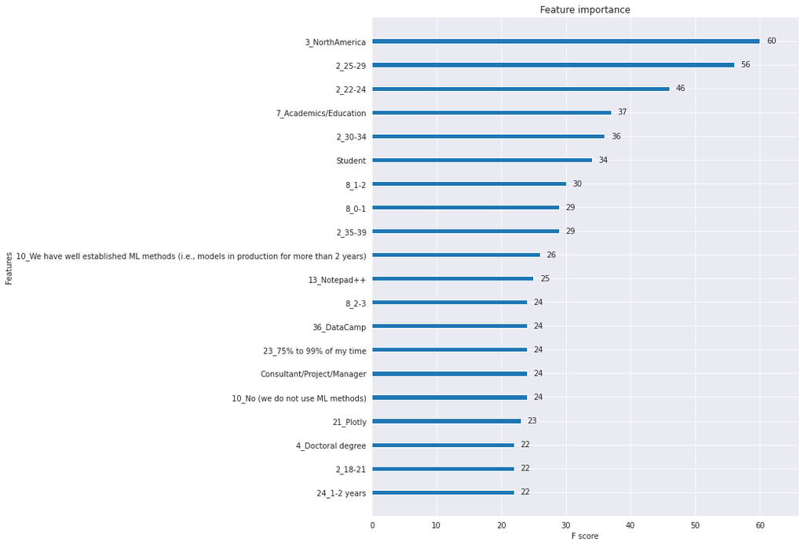

```python
%matplotlib inline

fig, ax = plt.subplots(figsize=(10, 12))

plot_importance(xgb_tuned, ax=ax, max_num_features = 20)
```